# Supervised Learning : Exploring Performance Evaluation Metrics for Survival Prediction

John Pauline Pineda

March 10, 2023

# **1. Table of Contents**

This project explores different performance metrics which are adaptable to censoring conditions for evaluating survival model predictions using various helpful packages in **R**. Using the **Survival Random Forest** and **Cox Proportional Hazards Regression** model structures, metrics applied in the analysis to estimate the generalization performance of survival models on out-of-sample data included the **Concordance Index**, **Brier Score**, **Integrated Absolute Error** and **Integrated Square Error**. The resulting split-sample cross-validated estimations derived from the metrics were evaluated in terms of their performance consistency across the candidate models. Considering the differences in their intended applications and current data restrictions, a comparison of each metric’s strengths and limitations was briefly discussed. All results were consolidated in a **Summary** presented at the end of the document.  
Survival analysis aims to study the relationship between independent covariates and survival time and event outcomes. Evaluation metrics in survival analysis are used to ascertain the agreement between the predicted and actual measures for each observation (expressed in survival probability, status or time), while considering the censoring condition. The metrics applied in this study (mostly contained in the **SurvMetrics** package) attempt to evaluate the performance of survival model predictions on unseen data.

## 1.1 Sample Data

The **peakVO2** dataset from the **randomForestSRC** package was used for this illustrated example.  
Preliminary dataset assessment:  
**[A]** 2231 rows (observations)  
**[B]** 41 columns (variables)  
**[B.1]** 1/41 survival event status = died variable (factor)  
**[B.1.1]** Event = died=1  
**[B.1.2]** Censored or Non-Event = died=0  
**[B.2]** 1/41 survival time = ttodead variable (numeric)  
**[B.3]** 39/41 predictors = All remaining variables (26/39 factor + 13/39 numeric)

**Code Chunk | Output**

```r
##################################
# Loading R libraries
##################################
library(survival)
library(survminer)
library(mice)
library(foreign)
library(rms)
library(Hmisc)
library(VIM)
library(gridExtra)
library(finalfit)
library(knitr)
library(dplyr)
library(gtsummary)
library(tidyr)
library(purrr)
library(moments)
library(skimr)
library(caret)
library(corrplot)
library(randomForestSRC)
library(SurvMetrics)
library(pec)

##################################
# Loading source and
# formulating the train set
##################################
data(peakVO2)
peakVO2 <- as.data.frame(peakVO2)

##################################
# Converting survival time
# to discrete monthly data
##################################
peakVO2$ttodead <- ceiling(peakVO2$ttodead*12)
peakVO2.Source <- peakVO2

##################################
# Setting the appropriate data types
# for exploratory data analysis
##################################
peakVO2.Assessment <- (as.data.frame(sapply(peakVO2, function(x) max(x))))
names(peakVO2.Assessment) <- c("Max.Value")
peakVO2.Assessment$Variables <- rownames(peakVO2.Assessment)
peakVO2.Assessment
```

```
##                          Max.Value               Variables
## age                       82.00000                     age
## betablok                   1.00000                betablok
## dilver                     1.00000                  dilver
## nifed                      1.00000                   nifed
## acei                       1.00000                    acei
## angioten.II                1.00000             angioten.II
## anti.arrhy                 1.00000              anti.arrhy
## anti.coag                  1.00000               anti.coag
## aspirin                    1.00000                 aspirin
## digoxin                    1.00000                 digoxin
## nitrates                   1.00000                nitrates
## vasodilator                1.00000             vasodilator
## diuretic.loop              1.00000           diuretic.loop
## diuretic.thiazide          1.00000       diuretic.thiazide
## diuretic.potassium.spar    1.00000 diuretic.potassium.spar
## lipidrx.statin             1.00000          lipidrx.statin
## insulin                    1.00000                 insulin
## surgery.pacemaker          1.00000       surgery.pacemaker
## surgery.cabg               1.00000            surgery.cabg
## surgery.pci                1.00000             surgery.pci
## surgery.aicd.implant       1.00000    surgery.aicd.implant
## resting.systolic.bp      184.00000     resting.systolic.bp
## resting.hr               124.00000              resting.hr
## smknow                     1.00000                  smknow
## q.wave.mi                  1.00000               q.wave.mi
## bmi                       59.61593                     bmi
## niddm                      1.00000                   niddm
## lvef.metabl               40.00000             lvef.metabl
## peak.rer                   1.80000                peak.rer
## peak.vo2                  43.80000                peak.vo2
## interval                1415.00000                interval
## cad                        1.00000                     cad
## died                       1.00000                    died
## ttodead                  127.00000                 ttodead
## bun                      129.00000                     bun
## sodium                   152.00000                  sodium
## hgb                       19.20000                     hgb
## glucose                  424.00000                 glucose
## male                       1.00000                    male
## black                      1.00000                   black
## crcl                     385.84097                    crcl
```

```r
(peakVO2.FactorNames <- peakVO2.Assessment[peakVO2.Assessment[,1]==1,2])
```

```
##  [1] "betablok"                "dilver"
##  [3] "nifed"                   "acei"
##  [5] "angioten.II"             "anti.arrhy"
##  [7] "anti.coag"               "aspirin"
##  [9] "digoxin"                 "nitrates"
## [11] "vasodilator"             "diuretic.loop"
## [13] "diuretic.thiazide"       "diuretic.potassium.spar"
## [15] "lipidrx.statin"          "insulin"
## [17] "surgery.pacemaker"       "surgery.cabg"
## [19] "surgery.pci"             "surgery.aicd.implant"
## [21] "smknow"                  "q.wave.mi"
## [23] "niddm"                   "cad"
## [25] "died"                    "male"
## [27] "black"
```

```r
peakVO2.Factor <- peakVO2[,peakVO2.FactorNames]
peakVO2.Factor <- as.data.frame(lapply(peakVO2.Factor, factor))

peakVO2.Numeric <- as.data.frame(peakVO2[,!names(peakVO2) %in% peakVO2.FactorNames])

peakVO2 <- data.frame(peakVO2.Numeric,peakVO2.Factor)

##################################
# Performing a general exploration of the data set
##################################
dim(peakVO2)
```

```
## [1] 2231   41
```

```r
str(peakVO2)
```

```
## 'data.frame':    2231 obs. of  41 variables:
##  $ age                    : int  74 77 79 67 79 51 56 69 41 45 ...
##  $ resting.systolic.bp    : int  90 134 108 122 130 122 100 104 108 100 ...
##  $ resting.hr             : int  74 53 104 96 94 62 79 72 71 84 ...
##  $ bmi                    : num  26.1 20.8 20.7 26.7 23.6 ...
##  $ lvef.metabl            : num  15 20 40 25 20 10 10 15 20 25 ...
##  $ peak.rer               : num  1.12 0.98 1.15 1.21 1.06 0.98 0.91 1.2 1.17 0.89 ...
##  $ peak.vo2               : num  11.9 24 11.2 15.6 17.2 15.7 6 15.9 23.8 15 ...
##  $ interval               : int  374 755 225 405 580 635 145 480 840 453 ...
##  $ ttodead                : num  15 44 3 127 45 15 13 11 122 9 ...
##  $ bun                    : num  25 20 29.7 27.9 39 ...
##  $ sodium                 : num  141 138 140 139 143 ...
##  $ hgb                    : num  14.6 13.1 12.9 13.2 12.5 ...
##  $ glucose                : num  89 90 98.7 136.9 104 ...
##  $ crcl                   : num  49.9 60.4 33.6 69.3 44.7 ...
```

[output cut: 27 more lines]

```r
summary(peakVO2)
```

```
##       age        resting.systolic.bp   resting.hr          bmi
##  Min.   :18.00   Min.   : 80.0       Min.   : 39.00   Min.   :14.18
##  1st Qu.:48.00   1st Qu.: 98.0       1st Qu.: 66.00   1st Qu.:24.52
##  Median :55.00   Median :110.0       Median : 75.00   Median :27.78
##  Mean   :54.22   Mean   :110.5       Mean   : 76.18   Mean   :28.50
##  3rd Qu.:62.00   3rd Qu.:122.0       3rd Qu.: 86.00   3rd Qu.:31.89
##  Max.   :82.00   Max.   :184.0       Max.   :124.00   Max.   :59.62
##   lvef.metabl       peak.rer        peak.vo2        interval
##  Min.   : 5.00   Min.   :0.079   Min.   : 4.20   Min.   :  21.0
##  1st Qu.:15.00   1st Qu.:1.020   1st Qu.:12.80   1st Qu.: 345.0
##  Median :20.00   Median :1.100   Median :15.70   Median : 480.0
##  Mean   :20.26   Mean   :1.079   Mean   :16.27   Mean   : 503.3
##  3rd Qu.:25.00   3rd Qu.:1.140   3rd Qu.:19.30   3rd Qu.: 641.0
##  Max.   :40.00   Max.   :1.800   Max.   :43.80   Max.   :1415.0
##     ttodead            bun              sodium           hgb
##  Min.   :  1.00   Min.   :  4.322   Min.   :120.0   Min.   : 7.20
##  1st Qu.: 30.00   1st Qu.: 17.000   1st Qu.:138.0   1st Qu.:12.80
##  Median : 62.00   Median : 23.000   Median :139.8   Median :13.58
##  Mean   : 62.75   Mean   : 25.278   Mean   :139.5   Mean   :13.54
##  3rd Qu.: 95.00   3rd Qu.: 29.334   3rd Qu.:141.0   3rd Qu.:14.40
##  Max.   :127.00   Max.   :129.000   Max.   :152.0   Max.   :19.20
##     glucose            crcl        betablok dilver   nifed    acei
##  Min.   : 37.00   Min.   :  5.76   0: 802   0:2215   0:2132   0: 520
##  1st Qu.: 87.00   1st Qu.: 60.93   1:1429   1:  16   1:  99   1:1711
##  Median : 96.93   Median : 83.13
##  Mean   :109.35   Mean   : 90.71
##  3rd Qu.:114.88   3rd Qu.:110.33
##  Max.   :424.00   Max.   :385.84
##  angioten.II anti.arrhy anti.coag aspirin  digoxin  nitrates vasodilator
##  0:1941      0:1722     0:1332    0:1193   0: 661   0:1492   0:2095
##  1: 290      1: 509     1: 899    1:1038   1:1570   1: 739   1: 136
##
##
##
##
##  diuretic.loop diuretic.thiazide diuretic.potassium.spar lipidrx.statin
##  0: 351        0:1952            0:1582                  0:1381
##  1:1880        1: 279            1: 649                  1: 850
##
##
##
##
##  insulin  surgery.pacemaker surgery.cabg surgery.pci surgery.aicd.implant
##  0:2016   0:1729            0:1637       0:1755      0:1584
##  1: 215   1: 502            1: 594       1: 476      1: 647
##
##
##
##
##  smknow   q.wave.mi niddm    cad      died     male     black
##  0:1772   0:1952    0:1881   0:1325   0:1505   0: 602   0:1965
##  1: 459   1: 279    1: 350   1: 906   1: 726   1:1629   1: 266
##
##
##
##
```

```r
##################################
# Formulating a data type assessment summary
##################################
PDA <- peakVO2
(PDA.Summary <- data.frame(
  Column.Index=c(1:length(names(PDA))),
  Column.Name= names(PDA),
  Column.Type=sapply(PDA, function(x) class(x)),
  row.names=NULL)
)
```

```
##    Column.Index             Column.Name Column.Type
## 1             1                     age     integer
## 2             2     resting.systolic.bp     integer
## 3             3              resting.hr     integer
## 4             4                     bmi     numeric
## 5             5             lvef.metabl     numeric
## 6             6                peak.rer     numeric
## 7             7                peak.vo2     numeric
## 8             8                interval     integer
## 9             9                 ttodead     numeric
## 10           10                     bun     numeric
## 11           11                  sodium     numeric
## 12           12                     hgb     numeric
## 13           13                 glucose     numeric
## 14           14                    crcl     numeric
```

[output cut: 27 more lines]

## 1.2 Data Quality Assessment

**[A]** No missing observations noted for any variable.  
**[B]** Low variance observed for 10 variables with First.Second.Mode.Ratio>5.  
**[B.1]** dilver variable (factor)  
**[B.2]** nifed variable (factor)  
**[B.3]** angioten.II variable (factor)  
**[B.4]** vasodilator variable (factor)  
**[B.5]** diuretic.loop variable (factor)  
**[B.6]** diuretic.thiazide variable (factor)  
**[B.7]** insulin variable (factor)  
**[B.8]** q.wave.mi variable (factor)  
**[B.9]** niddm variable (factor)  
**[B.10]** black variable (factor)  
**[C]** No low variance observed for any variable with Unique.Count.Ratio<0.01.  
**[D]** No high skewness observed for any variable with Skewness>3 or Skewness<(-3).

**Code Chunk | Output**

```r
##################################
# Loading dataset
##################################
DQA <- peakVO2

##################################
# Formulating an overall data quality assessment summary
##################################
(DQA.Summary <- data.frame(
  Column.Index=c(1:length(names(DQA))),
  Column.Name= names(DQA),
  Column.Type=sapply(DQA, function(x) class(x)),
  Row.Count=sapply(DQA, function(x) nrow(DQA)),
  NA.Count=sapply(DQA,function(x)sum(is.na(x))),
  Fill.Rate=sapply(DQA,function(x)format(round((sum(!is.na(x))/nrow(DQA)),3),nsmall=3)),
  row.names=NULL)
)
```

```
##    Column.Index             Column.Name Column.Type Row.Count NA.Count
## 1             1                     age     integer      2231        0
## 2             2     resting.systolic.bp     integer      2231        0
## 3             3              resting.hr     integer      2231        0
## 4             4                     bmi     numeric      2231        0
## 5             5             lvef.metabl     numeric      2231        0
## 6             6                peak.rer     numeric      2231        0
## 7             7                peak.vo2     numeric      2231        0
## 8             8                interval     integer      2231        0
## 9             9                 ttodead     numeric      2231        0
## 10           10                     bun     numeric      2231        0
## 11           11                  sodium     numeric      2231        0
## 12           12                     hgb     numeric      2231        0
## 13           13                 glucose     numeric      2231        0
## 14           14                    crcl     numeric      2231        0
```

[output cut: 69 more lines]

```r
##################################
# Listing all descriptors
##################################
DQA.Descriptors <- DQA

##################################
# Listing all numeric Descriptors
##################################
DQA.Descriptors.Numeric <- DQA.Descriptors[,sapply(DQA.Descriptors, is.numeric)]

if (length(names(DQA.Descriptors.Numeric))>0) {
    print(paste0("There are ",
               (length(names(DQA.Descriptors.Numeric))),
               " numeric descriptor variable(s)."))
} else {
  print("There are no numeric descriptor variables.")
}
```

```
## [1] "There are 14 numeric descriptor variable(s)."
```

```r
##################################
# Listing all factor Descriptors
##################################
DQA.Descriptors.Factor <- DQA.Descriptors[,sapply(DQA.Descriptors, is.factor)]

if (length(names(DQA.Descriptors.Factor))>0) {
    print(paste0("There are ",
               (length(names(DQA.Descriptors.Factor))),
               " factor descriptor variable(s)."))
} else {
  print("There are no factor descriptor variables.")
}
```

```
## [1] "There are 27 factor descriptor variable(s)."
```

```r
##################################
# Formulating a data quality assessment summary for factor Descriptors
##################################
if (length(names(DQA.Descriptors.Factor))>0) {

  ##################################
  # Formulating a function to determine the first mode
  ##################################
  FirstModes <- function(x) {
    ux <- unique(na.omit(x))
    tab <- tabulate(match(x, ux))
    ux[tab == max(tab)]
  }

  ##################################
  # Formulating a function to determine the second mode
  ##################################
  SecondModes <- function(x) {
    ux <- unique(na.omit(x))
    tab <- tabulate(match(x, ux))
    fm = ux[tab == max(tab)]
    sm = x[!(x %in% fm)]
    usm <- unique(sm)
    tabsm <- tabulate(match(sm, usm))
    ifelse(is.na(usm[tabsm == max(tabsm)])==TRUE,
           return("x"),
           return(usm[tabsm == max(tabsm)]))
  }

  (DQA.Descriptors.Factor.Summary <- data.frame(
  Column.Name= names(DQA.Descriptors.Factor),
  Column.Type=sapply(DQA.Descriptors.Factor, function(x) class(x)),
  Unique.Count=sapply(DQA.Descriptors.Factor, function(x) length(unique(x))),
  First.Mode.Value=sapply(DQA.Descriptors.Factor, function(x) as.character(FirstModes(x)[1])),
  Second.Mode.Value=sapply(DQA.Descriptors.Factor, function(x) as.character(SecondModes(x)[1])),
  First.Mode.Count=sapply(DQA.Descriptors.Factor, function(x) sum(na.omit(x) == FirstModes(x)[1])),
  Second.Mode.Count=sapply(DQA.Descriptors.Factor, function(x) sum(na.omit(x) == SecondModes(x)[1])),
  Unique.Count.Ratio=sapply(DQA.Descriptors.Factor, function(x) format(round((length(unique(x))/nrow(DQA.Descriptors.Factor)),3), nsmall=3)),
  First.Second.Mode.Ratio=sapply(DQA.Descriptors.Factor, function(x) format(round((sum(na.omit(x) == FirstModes(x)[1])/sum(na.omit(x) == SecondModes(x)[1])),3), nsmall=3)),
  row.names=NULL)
  )

}
```

```
##                Column.Name Column.Type Unique.Count First.Mode.Value
## 1                 betablok      factor            2                1
## 2                   dilver      factor            2                0
## 3                    nifed      factor            2                0
## 4                     acei      factor            2                1
## 5              angioten.II      factor            2                0
## 6               anti.arrhy      factor            2                0
## 7                anti.coag      factor            2                0
## 8                  aspirin      factor            2                0
## 9                  digoxin      factor            2                1
## 10                nitrates      factor            2                0
## 11             vasodilator      factor            2                0
## 12           diuretic.loop      factor            2                1
## 13       diuretic.thiazide      factor            2                0
## 14 diuretic.potassium.spar      factor            2                0
```

[output cut: 69 more lines]

```r
##################################
# Formulating a data quality assessment summary for numeric Descriptors
##################################
if (length(names(DQA.Descriptors.Numeric))>0) {

  ##################################
  # Formulating a function to determine the first mode
  ##################################
  FirstModes <- function(x) {
    ux <- unique(na.omit(x))
    tab <- tabulate(match(x, ux))
    ux[tab == max(tab)]
  }

  ##################################
  # Formulating a function to determine the second mode
  ##################################
  SecondModes <- function(x) {
    ux <- unique(na.omit(x))
    tab <- tabulate(match(x, ux))
    fm = ux[tab == max(tab)]
    sm = na.omit(x)[!(na.omit(x) %in% fm)]
    usm <- unique(sm)
    tabsm <- tabulate(match(sm, usm))
    ifelse(is.na(usm[tabsm == max(tabsm)])==TRUE,
           return(0.00001),
           return(usm[tabsm == max(tabsm)]))
  }

  (DQA.Descriptors.Numeric.Summary <- data.frame(
  Column.Name= names(DQA.Descriptors.Numeric),
  Column.Type=sapply(DQA.Descriptors.Numeric, function(x) class(x)),
  Unique.Count=sapply(DQA.Descriptors.Numeric, function(x) length(unique(x))),
  Unique.Count.Ratio=sapply(DQA.Descriptors.Numeric, function(x) format(round((length(unique(x))/nrow(DQA.Descriptors.Numeric)),3), nsmall=3)),
  First.Mode.Value=sapply(DQA.Descriptors.Numeric, function(x) format(round((FirstModes(x)[1]),3),nsmall=3)),
  Second.Mode.Value=sapply(DQA.Descriptors.Numeric, function(x) format(round((SecondModes(x)[1]),3),nsmall=3)),
  First.Mode.Count=sapply(DQA.Descriptors.Numeric, function(x) sum(na.omit(x) == FirstModes(x)[1])),
  Second.Mode.Count=sapply(DQA.Descriptors.Numeric, function(x) sum(na.omit(x) == SecondModes(x)[1])),
  First.Second.Mode.Ratio=sapply(DQA.Descriptors.Numeric, function(x) format(round((sum(na.omit(x) == FirstModes(x)[1])/sum(na.omit(x) == SecondModes(x)[1])),3), nsmall=3)),
  Minimum=sapply(DQA.Descriptors.Numeric, function(x) format(round(min(x,na.rm = TRUE),3), nsmall=3)),
  Mean=sapply(DQA.Descriptors.Numeric, function(x) format(round(mean(x,na.rm = TRUE),3), nsmall=3)),
  Median=sapply(DQA.Descriptors.Numeric, function(x) format(round(median(x,na.rm = TRUE),3), nsmall=3)),
  Maximum=sapply(DQA.Descriptors.Numeric, function(x) format(round(max(x,na.rm = TRUE),3), nsmall=3)),
  Skewness=sapply(DQA.Descriptors.Numeric, function(x) format(round(skewness(x,na.rm = TRUE),3), nsmall=3)),
  Kurtosis=sapply(DQA.Descriptors.Numeric, function(x) format(round(kurtosis(x,na.rm = TRUE),3), nsmall=3)),
  Percentile25th=sapply(DQA.Descriptors.Numeric, function(x) format(round(quantile(x,probs=0.25,na.rm = TRUE),3), nsmall=3)),
  Percentile75th=sapply(DQA.Descriptors.Numeric, function(x) format(round(quantile(x,probs=0.75,na.rm = TRUE),3), nsmall=3)),
  row.names=NULL)
  )

}
```

```
##            Column.Name Column.Type Unique.Count Unique.Count.Ratio
## 1                  age     integer           65              0.029
## 2  resting.systolic.bp     integer           55              0.025
## 3           resting.hr     integer           82              0.037
## 4                  bmi     numeric         2144              0.961
## 5          lvef.metabl     numeric           38              0.017
## 6             peak.rer     numeric           75              0.034
## 7             peak.vo2     numeric          252              0.113
## 8             interval     integer          594              0.266
## 9              ttodead     numeric          127              0.057
## 10                 bun     numeric          936              0.420
## 11              sodium     numeric          881              0.395
## 12                 hgb     numeric         1004              0.450
## 13             glucose     numeric         1060              0.475
## 14                crcl     numeric         2213              0.992
```

[output cut: 45 more lines]

```r
##################################
# Identifying potential data quality issues
##################################

##################################
# Checking for missing observations
##################################
if ((nrow(DQA.Summary[DQA.Summary$NA.Count>0,]))>0){
  print(paste0("Missing observations noted for ",
               (nrow(DQA.Summary[DQA.Summary$NA.Count>0,])),
               " variable(s) with NA.Count>0 and Fill.Rate<1.0."))
  DQA.Summary[DQA.Summary$NA.Count>0,]
} else {
  print("No missing observations noted.")
}
```

```
## [1] "No missing observations noted."
```

```r
##################################
# Checking for zero or near-zero variance Descriptors
##################################
if (length(names(DQA.Descriptors.Factor))==0) {
  print("No factor descriptors noted.")
} else if (nrow(DQA.Descriptors.Factor.Summary[as.numeric(as.character(DQA.Descriptors.Factor.Summary$First.Second.Mode.Ratio))>5,])>0){
  print(paste0("Low variance observed for ",
               (nrow(DQA.Descriptors.Factor.Summary[as.numeric(as.character(DQA.Descriptors.Factor.Summary$First.Second.Mode.Ratio))>5,])),
               " factor variable(s) with First.Second.Mode.Ratio>5."))
  DQA.Descriptors.Factor.Summary[as.numeric(as.character(DQA.Descriptors.Factor.Summary$First.Second.Mode.Ratio))>5,]
} else {
  print("No low variance factor descriptors due to high first-second mode ratio noted.")
}
```

```
## [1] "Low variance observed for 10 factor variable(s) with First.Second.Mode.Ratio>5."
```

```
##          Column.Name Column.Type Unique.Count First.Mode.Value
## 2             dilver      factor            2                0
## 3              nifed      factor            2                0
## 5        angioten.II      factor            2                0
## 11       vasodilator      factor            2                0
## 12     diuretic.loop      factor            2                1
## 13 diuretic.thiazide      factor            2                0
## 16           insulin      factor            2                0
## 22         q.wave.mi      factor            2                0
## 23             niddm      factor            2                0
## 27             black      factor            2                0
##    Second.Mode.Value First.Mode.Count Second.Mode.Count Unique.Count.Ratio
## 2                  1             2215                16              0.001
## 3                  1             2132                99              0.001
## 5                  1             1941               290              0.001
```

[output cut: 18 more lines]

```r
if (length(names(DQA.Descriptors.Numeric))==0) {
  print("No numeric descriptors noted.")
} else if (nrow(DQA.Descriptors.Numeric.Summary[as.numeric(as.character(DQA.Descriptors.Numeric.Summary$First.Second.Mode.Ratio))>5,])>0){
  print(paste0("Low variance observed for ",
               (nrow(DQA.Descriptors.Numeric.Summary[as.numeric(as.character(DQA.Descriptors.Numeric.Summary$First.Second.Mode.Ratio))>5,])),
               " numeric variable(s) with First.Second.Mode.Ratio>5."))
  DQA.Descriptors.Numeric.Summary[as.numeric(as.character(DQA.Descriptors.Numeric.Summary$First.Second.Mode.Ratio))>5,]
} else {
  print("No low variance numeric descriptors due to high first-second mode ratio noted.")
}
```

```
## [1] "No low variance numeric descriptors due to high first-second mode ratio noted."
```

```r
if (length(names(DQA.Descriptors.Numeric))==0) {
  print("No numeric descriptors noted.")
} else if (nrow(DQA.Descriptors.Numeric.Summary[as.numeric(as.character(DQA.Descriptors.Numeric.Summary$Unique.Count.Ratio))<0.01,])>0){
  print(paste0("Low variance observed for ",
               (nrow(DQA.Descriptors.Numeric.Summary[as.numeric(as.character(DQA.Descriptors.Numeric.Summary$Unique.Count.Ratio))<0.01,])),
               " numeric variable(s) with Unique.Count.Ratio<0.01."))
  DQA.Descriptors.Numeric.Summary[as.numeric(as.character(DQA.Descriptors.Numeric.Summary$Unique.Count.Ratio))<0.01,]
} else {
  print("No low variance numeric descriptors due to low unique count ratio noted.")
}
```

```
## [1] "No low variance numeric descriptors due to low unique count ratio noted."
```

```r
##################################
# Checking for skewed Descriptors
##################################
if (length(names(DQA.Descriptors.Numeric))==0) {
  print("No numeric descriptors noted.")
} else if (nrow(DQA.Descriptors.Numeric.Summary[as.numeric(as.character(DQA.Descriptors.Numeric.Summary$Skewness))>3 |
                                               as.numeric(as.character(DQA.Descriptors.Numeric.Summary$Skewness))<(-3),])>0){
  print(paste0("High skewness observed for ",
  (nrow(DQA.Descriptors.Numeric.Summary[as.numeric(as.character(DQA.Descriptors.Numeric.Summary$Skewness))>3 |
                                               as.numeric(as.character(DQA.Descriptors.Numeric.Summary$Skewness))<(-3),])),
  " numeric variable(s) with Skewness>3 or Skewness<(-3)."))
  DQA.Descriptors.Numeric.Summary[as.numeric(as.character(DQA.Descriptors.Numeric.Summary$Skewness))>3 |
                                 as.numeric(as.character(DQA.Descriptors.Numeric.Summary$Skewness))<(-3),]
} else {
  print("No skewed numeric descriptors noted.")
}
```

```
## [1] "No skewed numeric descriptors noted."
```

## 1.3 Data Preprocessing

### 1.3.1 Outlier

**[A]** Outliers noted for 12 variables with the numeric data visualized through a boxplot including observations classified as suspected outliers using the IQR criterion. The IQR criterion means that all observations above the (75th percentile + 1.5 x IQR) or below the (25th percentile - 1.5 x IQR) are suspected outliers, where IQR is the difference between the third quartile (75th percentile) and first quartile (25th percentile). Outlier treatment for numerical stability remains optional depending on potential model requirements for the subsequent steps.  
**[A.1]** age variable (33 outliers detected)  
**[A.2]** resting.systolic.bp variable (26 outliers detected)  
**[A.3]** resting.hr variable (9 outliers detected)  
**[A.4]** bmi variable (34 outliers detected)  
**[A.5]** peak.rer variable (102 outliers detected)  
**[A.6]** peak.vo2 variable (40 outliers detected)  
**[A.7]** interval variable (25 outliers detected)  
**[A.8]** bun variable (116 outliers detected)  
**[A.9]** sodium variable (140 outliers detected)  
**[A.10]** hgb variable (83 outliers detected)  
**[A.11]** glucose variable (222 outliers detected)  
**[A.12]** crcl variable (82 outliers detected)

**Code Chunk | Output**

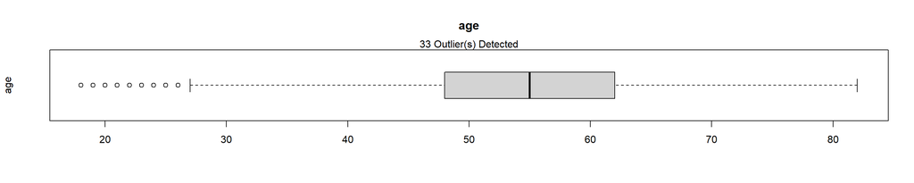

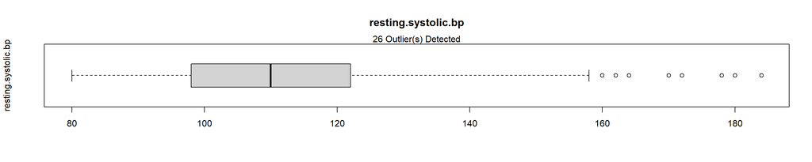

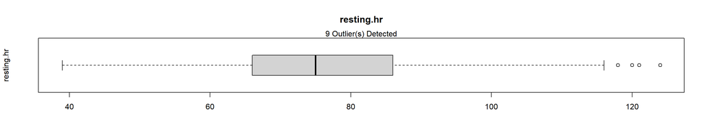

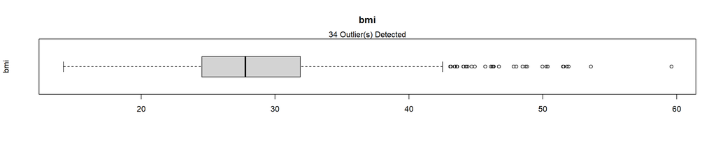

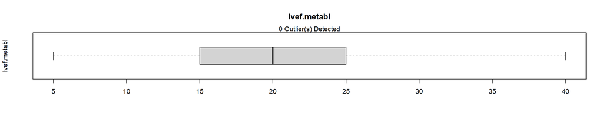

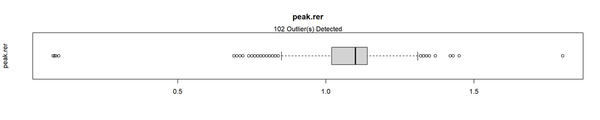

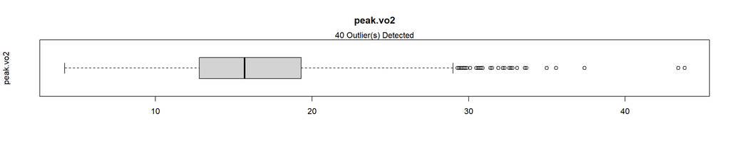

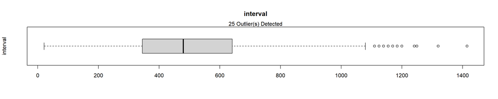

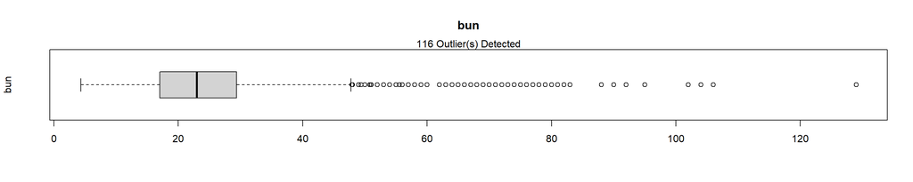

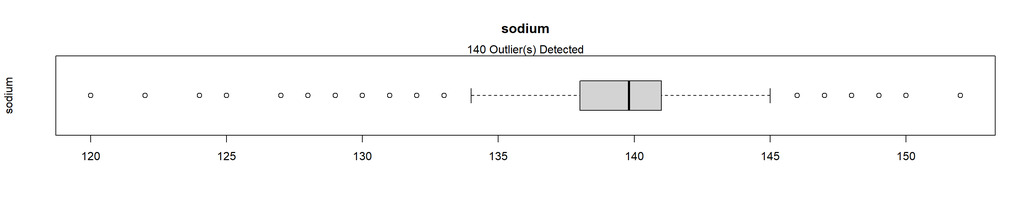

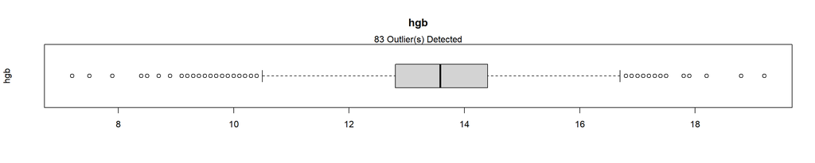

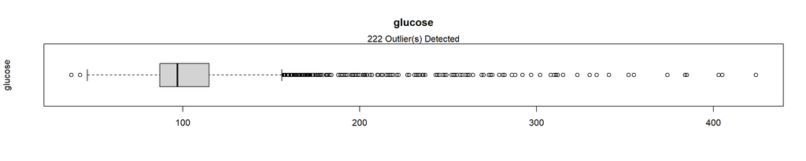

[1 more figures not shown]

```r
##################################
# Loading dataset
##################################
DPA <- peakVO2

##################################
# Listing all predictors
##################################
DPA.Predictors <- DPA[,!names(DPA) %in% c("died","ttodead")]

##################################
# Listing all numeric predictors
##################################
DPA.Predictors.Numeric <- DPA.Predictors[,sapply(DPA.Predictors, is.numeric)]

##################################
# Identifying outliers for the numeric predictors
##################################
OutlierCountList <- c()

for (i in 1:ncol(DPA.Predictors.Numeric)) {
  Outliers <- boxplot.stats(DPA.Predictors.Numeric[,i])$out
  OutlierCount <- length(Outliers)
  OutlierCountList <- append(OutlierCountList,OutlierCount)
  OutlierIndices <- which(DPA.Predictors.Numeric[,i] %in% c(Outliers))
  boxplot(DPA.Predictors.Numeric[,i],
          ylab = names(DPA.Predictors.Numeric)[i],
          main = names(DPA.Predictors.Numeric)[i],
          horizontal=TRUE)
  mtext(paste0(OutlierCount, " Outlier(s) Detected"))
}
```

```r
OutlierCountSummary <- as.data.frame(cbind(names(DPA.Predictors.Numeric),(OutlierCountList)))
names(OutlierCountSummary) <- c("NumericPredictors","OutlierCount")
OutlierCountSummary$OutlierCount <- as.numeric(as.character(OutlierCountSummary$OutlierCount))
NumericPredictorWithOutlierCount <- nrow(OutlierCountSummary[OutlierCountSummary$OutlierCount>0,])
print(paste0(NumericPredictorWithOutlierCount, " numeric variable(s) were noted with outlier(s)." ))
```

```
## [1] "12 numeric variable(s) were noted with outlier(s)."
```

```r
##################################
# Gathering descriptive statistics
##################################
(DPA_Skimmed <- skim(DPA.Predictors.Numeric))
```

Data summary

| Name | DPA.Predictors.Numeric |
| --- | --- |
| Number of rows | 2231 |
| Number of columns | 13 |
| _______________________ |  |
| Column type frequency: |  |
| numeric | 13 |
| ________________________ |  |
| Group variables | None |

**Variable type: numeric**

| skim_variable | n_missing | complete_rate | mean | sd | p0 | p25 | p50 | p75 | p100 | hist |
| --- | --- | --- | --- | --- | --- | --- | --- | --- | --- | --- |
| age | 0 | 1 | 54.22 | 11.03 | 18.00 | 48.00 | 55.00 | 62.00 | 82.00 | ▁▃▇▇▂ |
| resting.systolic.bp | 0 | 1 | 110.51 | 17.93 | 80.00 | 98.00 | 110.00 | 122.00 | 184.00 | ▇▇▅▁▁ |
| resting.hr | 0 | 1 | 76.18 | 14.39 | 39.00 | 66.00 | 75.00 | 86.00 | 124.00 | ▂▇▇▃▁ |
| bmi | 0 | 1 | 28.50 | 5.69 | 14.18 | 24.52 | 27.78 | 31.89 | 59.62 | ▂▇▃▁▁ |
| lvef.metabl | 0 | 1 | 20.26 | 7.34 | 5.00 | 15.00 | 20.00 | 25.00 | 40.00 | ▂▅▇▂▁ |
| peak.rer | 0 | 1 | 1.08 | 0.12 | 0.08 | 1.02 | 1.10 | 1.14 | 1.80 | ▁▁▇▆▁ |
| peak.vo2 | 0 | 1 | 16.27 | 5.03 | 4.20 | 12.80 | 15.70 | 19.30 | 43.80 | ▃▇▂▁▁ |
| interval | 0 | 1 | 503.26 | 220.86 | 21.00 | 345.00 | 480.00 | 641.00 | 1415.00 | ▃▇▅▁▁ |
| bun | 0 | 1 | 25.28 | 12.57 | 4.32 | 17.00 | 23.00 | 29.33 | 129.00 | ▇▂▁▁▁ |
| sodium | 0 | 1 | 139.45 | 3.09 | 120.00 | 138.00 | 139.80 | 141.00 | 152.00 | ▁▁▆▇▁ |
| hgb | 0 | 1 | 13.54 | 1.41 | 7.20 | 12.80 | 13.58 | 14.40 | 19.20 | ▁▂▇▃▁ |
| glucose | 0 | 1 | 109.35 | 42.56 | 37.00 | 87.00 | 96.93 | 114.88 | 424.00 | ▇▂▁▁▁ |
| crcl | 0 | 1 | 90.71 | 43.05 | 5.76 | 60.93 | 83.13 | 110.33 | 385.84 | ▇▇▁▁▁ |

```r
###################################
# Verifying the data dimensions
###################################
dim(DPA.Predictors.Numeric)
```

```
## [1] 2231   13
```

### 1.3.2 Zero and Near-Zero Variance

**[A]** Low variance noted for 10 variables from the previous data quality assessment using a lower threshold.  
**[B]** Low variance noted for 2 variables using a preprocessing summary from the **caret** package. The nearZeroVar method using both the freqCut and uniqueCut criteria set at 95/5 and 10, respectively, were applied on the dataset.  
**[B.1]** dilver variable (factor)  
**[B.2]** nifed variable (factor)

**Code Chunk | Output**

```r
##################################
# Loading dataset
##################################
DPA <- peakVO2

##################################
# Gathering descriptive statistics
##################################
(DPA_Skimmed <- skim(DPA))
```

Data summary

| Name | DPA |
| --- | --- |
| Number of rows | 2231 |
| Number of columns | 41 |
| _______________________ |  |
| Column type frequency: |  |
| factor | 27 |
| numeric | 14 |
| ________________________ |  |
| Group variables | None |

**Variable type: factor**

| skim_variable | n_missing | complete_rate | ordered | n_unique | top_counts |
| --- | --- | --- | --- | --- | --- |
| betablok | 0 | 1 | FALSE | 2 | 1: 1429, 0: 802 |
| dilver | 0 | 1 | FALSE | 2 | 0: 2215, 1: 16 |
| nifed | 0 | 1 | FALSE | 2 | 0: 2132, 1: 99 |
| acei | 0 | 1 | FALSE | 2 | 1: 1711, 0: 520 |
| angioten.II | 0 | 1 | FALSE | 2 | 0: 1941, 1: 290 |
| anti.arrhy | 0 | 1 | FALSE | 2 | 0: 1722, 1: 509 |
| anti.coag | 0 | 1 | FALSE | 2 | 0: 1332, 1: 899 |
| aspirin | 0 | 1 | FALSE | 2 | 0: 1193, 1: 1038 |
| digoxin | 0 | 1 | FALSE | 2 | 1: 1570, 0: 661 |
| nitrates | 0 | 1 | FALSE | 2 | 0: 1492, 1: 739 |
| vasodilator | 0 | 1 | FALSE | 2 | 0: 2095, 1: 136 |
| diuretic.loop | 0 | 1 | FALSE | 2 | 1: 1880, 0: 351 |
| diuretic.thiazide | 0 | 1 | FALSE | 2 | 0: 1952, 1: 279 |
| diuretic.potassium.spar | 0 | 1 | FALSE | 2 | 0: 1582, 1: 649 |
| lipidrx.statin | 0 | 1 | FALSE | 2 | 0: 1381, 1: 850 |
| insulin | 0 | 1 | FALSE | 2 | 0: 2016, 1: 215 |
| surgery.pacemaker | 0 | 1 | FALSE | 2 | 0: 1729, 1: 502 |
| surgery.cabg | 0 | 1 | FALSE | 2 | 0: 1637, 1: 594 |
| surgery.pci | 0 | 1 | FALSE | 2 | 0: 1755, 1: 476 |
| surgery.aicd.implant | 0 | 1 | FALSE | 2 | 0: 1584, 1: 647 |
| smknow | 0 | 1 | FALSE | 2 | 0: 1772, 1: 459 |
| q.wave.mi | 0 | 1 | FALSE | 2 | 0: 1952, 1: 279 |
| niddm | 0 | 1 | FALSE | 2 | 0: 1881, 1: 350 |
| cad | 0 | 1 | FALSE | 2 | 0: 1325, 1: 906 |
| died | 0 | 1 | FALSE | 2 | 0: 1505, 1: 726 |
| male | 0 | 1 | FALSE | 2 | 1: 1629, 0: 602 |
| black | 0 | 1 | FALSE | 2 | 0: 1965, 1: 266 |

**Variable type: numeric**

| skim_variable | n_missing | complete_rate | mean | sd | p0 | p25 | p50 | p75 | p100 | hist |
| --- | --- | --- | --- | --- | --- | --- | --- | --- | --- | --- |
| age | 0 | 1 | 54.22 | 11.03 | 18.00 | 48.00 | 55.00 | 62.00 | 82.00 | ▁▃▇▇▂ |
| resting.systolic.bp | 0 | 1 | 110.51 | 17.93 | 80.00 | 98.00 | 110.00 | 122.00 | 184.00 | ▇▇▅▁▁ |
| resting.hr | 0 | 1 | 76.18 | 14.39 | 39.00 | 66.00 | 75.00 | 86.00 | 124.00 | ▂▇▇▃▁ |
| bmi | 0 | 1 | 28.50 | 5.69 | 14.18 | 24.52 | 27.78 | 31.89 | 59.62 | ▂▇▃▁▁ |
| lvef.metabl | 0 | 1 | 20.26 | 7.34 | 5.00 | 15.00 | 20.00 | 25.00 | 40.00 | ▂▅▇▂▁ |
| peak.rer | 0 | 1 | 1.08 | 0.12 | 0.08 | 1.02 | 1.10 | 1.14 | 1.80 | ▁▁▇▆▁ |
| peak.vo2 | 0 | 1 | 16.27 | 5.03 | 4.20 | 12.80 | 15.70 | 19.30 | 43.80 | ▃▇▂▁▁ |
| interval | 0 | 1 | 503.26 | 220.86 | 21.00 | 345.00 | 480.00 | 641.00 | 1415.00 | ▃▇▅▁▁ |
| ttodead | 0 | 1 | 62.75 | 36.77 | 1.00 | 30.00 | 62.00 | 95.00 | 127.00 | ▇▇▇▇▇ |
| bun | 0 | 1 | 25.28 | 12.57 | 4.32 | 17.00 | 23.00 | 29.33 | 129.00 | ▇▂▁▁▁ |
| sodium | 0 | 1 | 139.45 | 3.09 | 120.00 | 138.00 | 139.80 | 141.00 | 152.00 | ▁▁▆▇▁ |
| hgb | 0 | 1 | 13.54 | 1.41 | 7.20 | 12.80 | 13.58 | 14.40 | 19.20 | ▁▂▇▃▁ |
| glucose | 0 | 1 | 109.35 | 42.56 | 37.00 | 87.00 | 96.93 | 114.88 | 424.00 | ▇▂▁▁▁ |
| crcl | 0 | 1 | 90.71 | 43.05 | 5.76 | 60.93 | 83.13 | 110.33 | 385.84 | ▇▇▁▁▁ |

```r
##################################
# Identifying columns with low variance
###################################
DPA_LowVariance <- nearZeroVar(DPA,
                               freqCut = 95/5,
                               uniqueCut = 10,
                               saveMetrics= TRUE)
(DPA_LowVariance[DPA_LowVariance$nzv,])
```

```
##        freqRatio percentUnique zeroVar  nzv
## dilver 138.43750     0.0896459   FALSE TRUE
## nifed   21.53535     0.0896459   FALSE TRUE
```

```r
if ((nrow(DPA_LowVariance[DPA_LowVariance$nzv,]))==0){

  print("No low variance predictors noted.")

} else {

  print(paste0("Low variance observed for ",
               (nrow(DPA_LowVariance[DPA_LowVariance$nzv,])),
               " numeric variable(s) with First.Second.Mode.Ratio>4 and Unique.Count.Ratio<0.10."))

  DPA_LowVarianceForRemoval <- (nrow(DPA_LowVariance[DPA_LowVariance$nzv,]))

  print(paste0("Low variance can be resolved by removing ",
               (nrow(DPA_LowVariance[DPA_LowVariance$nzv,])),
               " numeric variable(s)."))

  for (j in 1:DPA_LowVarianceForRemoval) {
  DPA_LowVarianceRemovedVariable <- rownames(DPA_LowVariance[DPA_LowVariance$nzv,])[j]
  print(paste0("Variable ",
               j,
               " for removal: ",
               DPA_LowVarianceRemovedVariable))
  }

  DPA %>%
  skim() %>%
  dplyr::filter(skim_variable %in% rownames(DPA_LowVariance[DPA_LowVariance$nzv,]))

  ##################################
  # Filtering out columns with low variance
  #################################
  DPA_ExcludedLowVariance <- DPA[,!names(DPA) %in% rownames(DPA_LowVariance[DPA_LowVariance$nzv,])]

  ##################################
  # Gathering descriptive statistics
  ##################################
  (DPA_ExcludedLowVariance_Skimmed <- skim(DPA_ExcludedLowVariance))
}
```

```
## [1] "Low variance observed for 2 numeric variable(s) with First.Second.Mode.Ratio>4 and Unique.Count.Ratio<0.10."
## [1] "Low variance can be resolved by removing 2 numeric variable(s)."
## [1] "Variable 1 for removal: dilver"
## [1] "Variable 2 for removal: nifed"
```

Data summary

| Name | DPA_ExcludedLowVariance |
| --- | --- |
| Number of rows | 2231 |
| Number of columns | 39 |
| _______________________ |  |
| Column type frequency: |  |
| factor | 25 |
| numeric | 14 |
| ________________________ |  |
| Group variables | None |

**Variable type: factor**

| skim_variable | n_missing | complete_rate | ordered | n_unique | top_counts |
| --- | --- | --- | --- | --- | --- |
| betablok | 0 | 1 | FALSE | 2 | 1: 1429, 0: 802 |
| acei | 0 | 1 | FALSE | 2 | 1: 1711, 0: 520 |
| angioten.II | 0 | 1 | FALSE | 2 | 0: 1941, 1: 290 |
| anti.arrhy | 0 | 1 | FALSE | 2 | 0: 1722, 1: 509 |
| anti.coag | 0 | 1 | FALSE | 2 | 0: 1332, 1: 899 |
| aspirin | 0 | 1 | FALSE | 2 | 0: 1193, 1: 1038 |
| digoxin | 0 | 1 | FALSE | 2 | 1: 1570, 0: 661 |
| nitrates | 0 | 1 | FALSE | 2 | 0: 1492, 1: 739 |
| vasodilator | 0 | 1 | FALSE | 2 | 0: 2095, 1: 136 |
| diuretic.loop | 0 | 1 | FALSE | 2 | 1: 1880, 0: 351 |
| diuretic.thiazide | 0 | 1 | FALSE | 2 | 0: 1952, 1: 279 |
| diuretic.potassium.spar | 0 | 1 | FALSE | 2 | 0: 1582, 1: 649 |
| lipidrx.statin | 0 | 1 | FALSE | 2 | 0: 1381, 1: 850 |
| insulin | 0 | 1 | FALSE | 2 | 0: 2016, 1: 215 |
| surgery.pacemaker | 0 | 1 | FALSE | 2 | 0: 1729, 1: 502 |
| surgery.cabg | 0 | 1 | FALSE | 2 | 0: 1637, 1: 594 |
| surgery.pci | 0 | 1 | FALSE | 2 | 0: 1755, 1: 476 |
| surgery.aicd.implant | 0 | 1 | FALSE | 2 | 0: 1584, 1: 647 |
| smknow | 0 | 1 | FALSE | 2 | 0: 1772, 1: 459 |
| q.wave.mi | 0 | 1 | FALSE | 2 | 0: 1952, 1: 279 |
| niddm | 0 | 1 | FALSE | 2 | 0: 1881, 1: 350 |
| cad | 0 | 1 | FALSE | 2 | 0: 1325, 1: 906 |
| died | 0 | 1 | FALSE | 2 | 0: 1505, 1: 726 |
| male | 0 | 1 | FALSE | 2 | 1: 1629, 0: 602 |
| black | 0 | 1 | FALSE | 2 | 0: 1965, 1: 266 |

**Variable type: numeric**

| skim_variable | n_missing | complete_rate | mean | sd | p0 | p25 | p50 | p75 | p100 | hist |
| --- | --- | --- | --- | --- | --- | --- | --- | --- | --- | --- |
| age | 0 | 1 | 54.22 | 11.03 | 18.00 | 48.00 | 55.00 | 62.00 | 82.00 | ▁▃▇▇▂ |
| resting.systolic.bp | 0 | 1 | 110.51 | 17.93 | 80.00 | 98.00 | 110.00 | 122.00 | 184.00 | ▇▇▅▁▁ |
| resting.hr | 0 | 1 | 76.18 | 14.39 | 39.00 | 66.00 | 75.00 | 86.00 | 124.00 | ▂▇▇▃▁ |
| bmi | 0 | 1 | 28.50 | 5.69 | 14.18 | 24.52 | 27.78 | 31.89 | 59.62 | ▂▇▃▁▁ |
| lvef.metabl | 0 | 1 | 20.26 | 7.34 | 5.00 | 15.00 | 20.00 | 25.00 | 40.00 | ▂▅▇▂▁ |
| peak.rer | 0 | 1 | 1.08 | 0.12 | 0.08 | 1.02 | 1.10 | 1.14 | 1.80 | ▁▁▇▆▁ |
| peak.vo2 | 0 | 1 | 16.27 | 5.03 | 4.20 | 12.80 | 15.70 | 19.30 | 43.80 | ▃▇▂▁▁ |
| interval | 0 | 1 | 503.26 | 220.86 | 21.00 | 345.00 | 480.00 | 641.00 | 1415.00 | ▃▇▅▁▁ |
| ttodead | 0 | 1 | 62.75 | 36.77 | 1.00 | 30.00 | 62.00 | 95.00 | 127.00 | ▇▇▇▇▇ |
| bun | 0 | 1 | 25.28 | 12.57 | 4.32 | 17.00 | 23.00 | 29.33 | 129.00 | ▇▂▁▁▁ |
| sodium | 0 | 1 | 139.45 | 3.09 | 120.00 | 138.00 | 139.80 | 141.00 | 152.00 | ▁▁▆▇▁ |
| hgb | 0 | 1 | 13.54 | 1.41 | 7.20 | 12.80 | 13.58 | 14.40 | 19.20 | ▁▂▇▃▁ |
| glucose | 0 | 1 | 109.35 | 42.56 | 37.00 | 87.00 | 96.93 | 114.88 | 424.00 | ▇▂▁▁▁ |
| crcl | 0 | 1 | 90.71 | 43.05 | 5.76 | 60.93 | 83.13 | 110.33 | 385.84 | ▇▇▁▁▁ |

### 1.3.3 Collinearity

**[A]** No high correlation > 95% noted for any variable pairs as confirmed using the preprocessing summaries from the **caret** and **lares** packages.

**Code Chunk | Output**

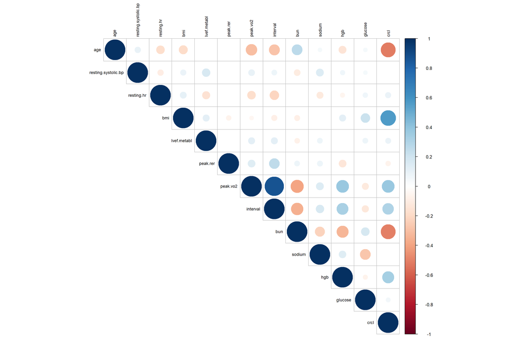

```r
##################################
# Loading dataset
##################################
DPA <- peakVO2

##################################
# Listing all predictors
##################################
DPA.Predictors <- DPA[,!names(DPA) %in% c("died","ttodead")]

##################################
# Listing all numeric predictors
##################################
DPA.Predictors.Numeric <- DPA.Predictors[,sapply(DPA.Predictors, is.numeric)]

##################################
# Visualizing pairwise correlation between predictors
##################################
DPA_CorrelationTest <- cor.mtest(DPA.Predictors.Numeric,
                       method = "pearson",
                       conf.level = .95)

corrplot(cor(DPA.Predictors.Numeric,
             method = "pearson",
             use="pairwise.complete.obs"),
         method = "circle",
         type = "upper",
         order = "original",
         tl.col = "black",
         tl.cex = 0.75,
         tl.srt = 90,
         sig.level = 0.05,
         p.mat = DPA_CorrelationTest$p,
         insig = "blank")
```

```r
##################################
# Identifying the highly correlated variables
##################################
DPA_Correlation <-  cor(DPA.Predictors.Numeric,
                        method = "pearson",
                        use="pairwise.complete.obs")
(DPA_HighlyCorrelatedCount <- sum(abs(DPA_Correlation[upper.tri(DPA_Correlation)]) > 0.95))
```

```
## [1] 0
```

```r
if (DPA_HighlyCorrelatedCount == 0) {
  print("No highly correlated predictors noted.")
} else {
  print(paste0("High correlation observed for ",
               (DPA_HighlyCorrelatedCount),
               " pairs of numeric variable(s) with Correlation.Coefficient>0.95."))

  (DPA_HighlyCorrelatedPairs <- corr_cross(DPA.Predictors.Numeric,
  max_pvalue = 0.05,
  top = DPA_HighlyCorrelatedCount,
  rm.na = TRUE,
  grid = FALSE
))

}
```

```
## [1] "No highly correlated predictors noted."
```

```r
if (DPA_HighlyCorrelatedCount > 0) {
  DPA_HighlyCorrelated <- findCorrelation(DPA_Correlation, cutoff = 0.95)

  (DPA_HighlyCorrelatedForRemoval <- length(DPA_HighlyCorrelated))

  print(paste0("High correlation can be resolved by removing ",
               (DPA_HighlyCorrelatedForRemoval),
               " numeric variable(s)."))

  for (j in 1:DPA_HighlyCorrelatedForRemoval) {
  DPA_HighlyCorrelatedRemovedVariable <- colnames(DPA.Predictors.Numeric)[DPA_HighlyCorrelated[j]]
  print(paste0("Variable ",
               j,
               " for removal: ",
               DPA_HighlyCorrelatedRemovedVariable))
  }

  ##################################
  # Filtering out columns with high correlation
  #################################
  DPA_ExcludedHighCorrelation <- DPA[,-DPA_HighlyCorrelated]

  ##################################
  # Gathering descriptive statistics
  ##################################
  (DPA_ExcludedHighCorrelation_Skimmed <- skim(DPA_ExcludedHighCorrelation))

}
```

### 1.3.4 Linear Dependencies

**[A]** No linear dependencies noted for any subset of variables using the preprocessing summary from the **caret** package applying the findLinearCombos method which utilizes the QR decomposition of a matrix to enumerate sets of linear combinations (if they exist).

**Code Chunk | Output**

```r
##################################
# Loading dataset
##################################
DPA <- peakVO2

##################################
# Listing all predictors
##################################
DPA.Predictors <- DPA[,!names(DPA) %in% c("died","ttodead")]

##################################
# Listing all numeric predictors
##################################
DPA.Predictors.Numeric <- DPA.Predictors[,sapply(DPA.Predictors, is.numeric)]

##################################
# Identifying the linearly dependent variables
##################################
DPA_LinearlyDependent <- findLinearCombos(DPA.Predictors.Numeric)

(DPA_LinearlyDependentCount <- length(DPA_LinearlyDependent$linearCombos))
```

```
## [1] 0
```

```r
if (DPA_LinearlyDependentCount == 0) {
  print("No linearly dependent predictors noted.")
} else {
  print(paste0("Linear dependency observed for ",
               (DPA_LinearlyDependentCount),
               " subset(s) of numeric variable(s)."))

  for (i in 1:DPA_LinearlyDependentCount) {
    DPA_LinearlyDependentSubset <- colnames(DPA.Predictors.Numeric)[DPA_LinearlyDependent$linearCombos[[i]]]
    print(paste0("Linear dependent variable(s) for subset ",
                 i,
                 " include: ",
                 DPA_LinearlyDependentSubset))
  }

}
```

```
## [1] "No linearly dependent predictors noted."
```

```r
##################################
# Identifying the linearly dependent variables for removal
##################################

if (DPA_LinearlyDependentCount > 0) {
  DPA_LinearlyDependent <- findLinearCombos(DPA.Predictors.Numeric)

  DPA_LinearlyDependentForRemoval <- length(DPA_LinearlyDependent$remove)

  print(paste0("Linear dependency can be resolved by removing ",
               (DPA_LinearlyDependentForRemoval),
               " numeric variable(s)."))

  for (j in 1:DPA_LinearlyDependentForRemoval) {
  DPA_LinearlyDependentRemovedVariable <- colnames(DPA.Predictors.Numeric)[DPA_LinearlyDependent$remove[j]]
  print(paste0("Variable ",
               j,
               " for removal: ",
               DPA_LinearlyDependentRemovedVariable))
  }

  ##################################
  # Filtering out columns with linear dependency
  #################################
  DPA_ExcludedLinearlyDependent <- DPA[,-DPA_LinearlyDependent$remove]

  ##################################
  # Gathering descriptive statistics
  ##################################
  (DPA_ExcludedLinearlyDependent_Skimmed <- skim(DPA_ExcludedLinearlyDependent))

}
```

### 1.3.5 Pre-Processed Dataset

**[A]** 2231 rows (observations)  
**[B]** 39 columns (variables)  
**[B.1]** 1/39 survival event status = died variable (factor)  
**[B.1.1]** Event = died=1  
**[B.1.2]** Censored or Non-Event = died=0  
**[B.2]** 1/39 survival time = ttodead variable (numeric)  
**[B.3]** 37/39 predictors = All remaining variables (24/39 factor + 13/39 numeric)  
**[C]** Pre-processing actions applied:  
**[C.1]** No centering, scaling and shape transformation applied to maintain interpretability  
**[C.2]** No outlier treatment applied since the high values noted were contextually valid and sensible  
**[C.3]** 2 predictors removed due to zero or near-zero variance  
**[C.4]** No predictors removed due to high correlation  
**[C.5]** No predictors removed due to linear dependencies

**Code Chunk | Output**

```r
##################################
# Filtering out columns noted with data quality issues including
# zero and near-zero variance,
# to create the pre-modelling dataset
##################################
PMA_ExcludedLowVariance <- peakVO2[,!names(peakVO2) %in% c("dilver","nifed")]

PMA_PreModelling_Train <- PMA_ExcludedLowVariance

##################################
# Gathering descriptive statistics
##################################
(PMA_PreModelling_Train_Skimmed <- skim(PMA_PreModelling_Train))
```

Data summary

| Name | PMA_PreModelling_Train |
| --- | --- |
| Number of rows | 2231 |
| Number of columns | 39 |
| _______________________ |  |
| Column type frequency: |  |
| factor | 25 |
| numeric | 14 |
| ________________________ |  |
| Group variables | None |

**Variable type: factor**

| skim_variable | n_missing | complete_rate | ordered | n_unique | top_counts |
| --- | --- | --- | --- | --- | --- |
| betablok | 0 | 1 | FALSE | 2 | 1: 1429, 0: 802 |
| acei | 0 | 1 | FALSE | 2 | 1: 1711, 0: 520 |
| angioten.II | 0 | 1 | FALSE | 2 | 0: 1941, 1: 290 |
| anti.arrhy | 0 | 1 | FALSE | 2 | 0: 1722, 1: 509 |
| anti.coag | 0 | 1 | FALSE | 2 | 0: 1332, 1: 899 |
| aspirin | 0 | 1 | FALSE | 2 | 0: 1193, 1: 1038 |
| digoxin | 0 | 1 | FALSE | 2 | 1: 1570, 0: 661 |
| nitrates | 0 | 1 | FALSE | 2 | 0: 1492, 1: 739 |
| vasodilator | 0 | 1 | FALSE | 2 | 0: 2095, 1: 136 |
| diuretic.loop | 0 | 1 | FALSE | 2 | 1: 1880, 0: 351 |
| diuretic.thiazide | 0 | 1 | FALSE | 2 | 0: 1952, 1: 279 |
| diuretic.potassium.spar | 0 | 1 | FALSE | 2 | 0: 1582, 1: 649 |
| lipidrx.statin | 0 | 1 | FALSE | 2 | 0: 1381, 1: 850 |
| insulin | 0 | 1 | FALSE | 2 | 0: 2016, 1: 215 |
| surgery.pacemaker | 0 | 1 | FALSE | 2 | 0: 1729, 1: 502 |
| surgery.cabg | 0 | 1 | FALSE | 2 | 0: 1637, 1: 594 |
| surgery.pci | 0 | 1 | FALSE | 2 | 0: 1755, 1: 476 |
| surgery.aicd.implant | 0 | 1 | FALSE | 2 | 0: 1584, 1: 647 |
| smknow | 0 | 1 | FALSE | 2 | 0: 1772, 1: 459 |
| q.wave.mi | 0 | 1 | FALSE | 2 | 0: 1952, 1: 279 |
| niddm | 0 | 1 | FALSE | 2 | 0: 1881, 1: 350 |
| cad | 0 | 1 | FALSE | 2 | 0: 1325, 1: 906 |
| died | 0 | 1 | FALSE | 2 | 0: 1505, 1: 726 |
| male | 0 | 1 | FALSE | 2 | 1: 1629, 0: 602 |
| black | 0 | 1 | FALSE | 2 | 0: 1965, 1: 266 |

**Variable type: numeric**

| skim_variable | n_missing | complete_rate | mean | sd | p0 | p25 | p50 | p75 | p100 | hist |
| --- | --- | --- | --- | --- | --- | --- | --- | --- | --- | --- |
| age | 0 | 1 | 54.22 | 11.03 | 18.00 | 48.00 | 55.00 | 62.00 | 82.00 | ▁▃▇▇▂ |
| resting.systolic.bp | 0 | 1 | 110.51 | 17.93 | 80.00 | 98.00 | 110.00 | 122.00 | 184.00 | ▇▇▅▁▁ |
| resting.hr | 0 | 1 | 76.18 | 14.39 | 39.00 | 66.00 | 75.00 | 86.00 | 124.00 | ▂▇▇▃▁ |
| bmi | 0 | 1 | 28.50 | 5.69 | 14.18 | 24.52 | 27.78 | 31.89 | 59.62 | ▂▇▃▁▁ |
| lvef.metabl | 0 | 1 | 20.26 | 7.34 | 5.00 | 15.00 | 20.00 | 25.00 | 40.00 | ▂▅▇▂▁ |
| peak.rer | 0 | 1 | 1.08 | 0.12 | 0.08 | 1.02 | 1.10 | 1.14 | 1.80 | ▁▁▇▆▁ |
| peak.vo2 | 0 | 1 | 16.27 | 5.03 | 4.20 | 12.80 | 15.70 | 19.30 | 43.80 | ▃▇▂▁▁ |
| interval | 0 | 1 | 503.26 | 220.86 | 21.00 | 345.00 | 480.00 | 641.00 | 1415.00 | ▃▇▅▁▁ |
| ttodead | 0 | 1 | 62.75 | 36.77 | 1.00 | 30.00 | 62.00 | 95.00 | 127.00 | ▇▇▇▇▇ |
| bun | 0 | 1 | 25.28 | 12.57 | 4.32 | 17.00 | 23.00 | 29.33 | 129.00 | ▇▂▁▁▁ |
| sodium | 0 | 1 | 139.45 | 3.09 | 120.00 | 138.00 | 139.80 | 141.00 | 152.00 | ▁▁▆▇▁ |
| hgb | 0 | 1 | 13.54 | 1.41 | 7.20 | 12.80 | 13.58 | 14.40 | 19.20 | ▁▂▇▃▁ |
| glucose | 0 | 1 | 109.35 | 42.56 | 37.00 | 87.00 | 96.93 | 114.88 | 424.00 | ▇▂▁▁▁ |
| crcl | 0 | 1 | 90.71 | 43.05 | 5.76 | 60.93 | 83.13 | 110.33 | 385.84 | ▇▇▁▁▁ |

```r
###################################
# Verifying the data dimensions
# for the train set
###################################
dim(PMA_PreModelling_Train)
```

```
## [1] 2231   39
```

## 1.4 Data Exploration

**Code Chunk | Output**

```r
##################################
# Loading dataset
##################################
EDA <- PMA_PreModelling_Train

##################################
# Loading dataset
##################################
EDA.DescriptiveStatistics <- EDA

EDA.DescriptiveStatistics$died <- ifelse(EDA.DescriptiveStatistics$died=="0","Survived+Censored","Died")

##################################
# Formulating a preliminary summary
# of descriptive statistics
##################################
EDA.DescriptiveStatistics %>%
  tbl_summary(
    by = died,
    type = all_continuous() ~ "continuous2",
    statistic = all_continuous() ~ c("{N_nonmiss}",
                                     "{mean} ({sd})",
                                     "{median} ({p25}, {p75})",
                                     "{min}, {max}"),
    missing = "no") %>%
  add_overall() %>%
  add_p()
```

| **Characteristic** | **Overall**, N = 2,231<sup>1</sup> | **Died**, N = 726<sup>1</sup> | **Survived+Censored**, N = 1,505<sup>1</sup> | **p-value**<sup>2</sup> |
| --- | --- | --- | --- | --- |
| age |  |  |  | <0.001 |
| N | 2,231 | 726 | 1,505 |  |
| Mean (SD) | 54 (11) | 56 (11) | 53 (11) |  |
| Median (IQR) | 55 (48, 62) | 58 (50, 64) | 54 (46, 61) |  |
| Range | 18, 82 | 18, 82 | 19, 82 |  |
| resting.systolic.bp |  |  |  | <0.001 |
| N | 2,231 | 726 | 1,505 |  |
| Mean (SD) | 111 (18) | 108 (18) | 112 (18) |  |
| Median (IQR) | 110 (98, 122) | 108 (94, 120) | 110 (100, 122) |  |
| Range | 80, 184 | 80, 184 | 80, 184 |  |
| resting.hr |  |  |  | <0.001 |
| N | 2,231 | 726 | 1,505 |  |
| Mean (SD) | 76 (14) | 79 (14) | 75 (14) |  |
| Median (IQR) | 75 (66, 86) | 78 (68, 88) | 74 (65, 84) |  |
| Range | 39, 124 | 41, 121 | 39, 124 |  |
| bmi |  |  |  | 0.031 |
| N | 2,231 | 726 | 1,505 |  |
| Mean (SD) | 28.5 (5.7) | 28.1 (5.5) | 28.7 (5.8) |  |
| Median (IQR) | 27.8 (24.5, 31.9) | 27.5 (24.4, 31.1) | 27.9 (24.6, 32.2) |  |
| Range | 14.2, 59.6 | 15.8, 51.9 | 14.2, 59.6 |  |
| lvef.metabl |  |  |  | <0.001 |
| N | 2,231 | 726 | 1,505 |  |
| Mean (SD) | 20 (7) | 19 (7) | 21 (7) |  |
| Median (IQR) | 20 (15, 25) | 20 (15, 25) | 20 (15, 25) |  |
| Range | 5, 40 | 5, 40 | 5, 40 |  |
| peak.rer |  |  |  | 0.028 |
| N | 2,231 | 726 | 1,505 |  |
| Mean (SD) | 1.08 (0.12) | 1.08 (0.11) | 1.08 (0.12) |  |
| Median (IQR) | 1.10 (1.02, 1.14) | 1.11 (1.03, 1.15) | 1.10 (1.02, 1.14) |  |
| Range | 0.08, 1.80 | 0.08, 1.35 | 0.08, 1.80 |  |

[output cut: 112 more lines]

<sup>1</sup> n (%)  
<sup>2</sup> Wilcoxon rank sum test; Pearson's Chi-squared test

```r
##################################
# Listing all predictors
##################################
EDA.Predictors <- EDA[,!names(EDA) %in% c("died","ttodead")]

##################################
# Listing all numeric predictors
##################################
EDA.Predictors.Numeric <- EDA.Predictors[,sapply(EDA.Predictors, is.numeric)]
ncol(EDA.Predictors.Numeric)
```

```
## [1] 13
```

```r
names(EDA.Predictors.Numeric)
```

```
##  [1] "age"                 "resting.systolic.bp" "resting.hr"
##  [4] "bmi"                 "lvef.metabl"         "peak.rer"
##  [7] "peak.vo2"            "interval"            "bun"
## [10] "sodium"              "hgb"                 "glucose"
## [13] "crcl"
```

```r
##################################
# Listing all factor predictors
##################################
EDA.Predictors.Factor <- EDA.Predictors[,sapply(EDA.Predictors, is.factor)]
ncol(EDA.Predictors.Factor)
```

```
## [1] 24
```

```r
names(EDA.Predictors.Factor)
```

```
##  [1] "betablok"                "acei"
##  [3] "angioten.II"             "anti.arrhy"
##  [5] "anti.coag"               "aspirin"
##  [7] "digoxin"                 "nitrates"
##  [9] "vasodilator"             "diuretic.loop"
## [11] "diuretic.thiazide"       "diuretic.potassium.spar"
## [13] "lipidrx.statin"          "insulin"
## [15] "surgery.pacemaker"       "surgery.cabg"
## [17] "surgery.pci"             "surgery.aicd.implant"
## [19] "smknow"                  "q.wave.mi"
## [21] "niddm"                   "cad"
## [23] "male"                    "black"
```

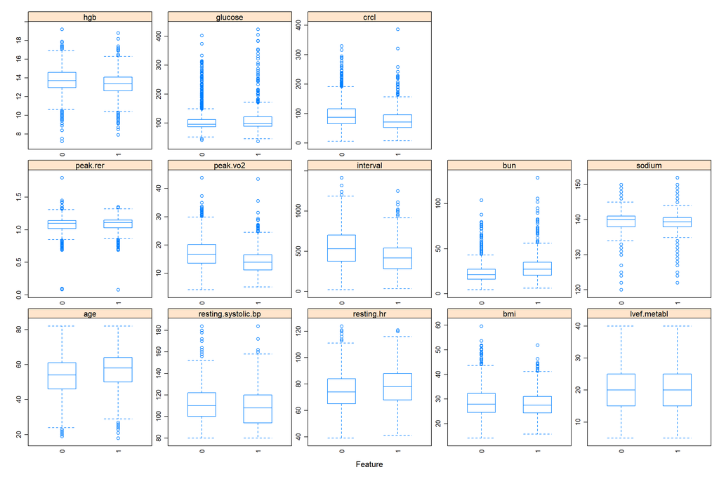

```r
##################################
# Formulating the box plots
##################################
featurePlot(x = EDA.Predictors.Numeric,
            y = EDA$died,
            plot = "box",
            scales = list(x = list(relation="free", rot = 90),
                          y = list(relation="free")),
            adjust = 1.5,
            pch = "|")
```

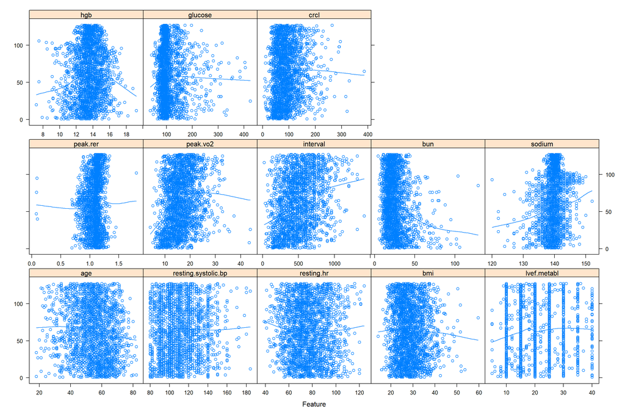

```r
##################################
# Formulating the scatter plot
##################################
featurePlot(x = EDA.Predictors.Numeric,
            y = EDA$ttodead,
            plot = "scatter",
            type = c("p", "smooth"),
            span = .5)
```

```r
##################################
# Restructuring the dataset for
# for barchart analysis
##################################
died <- EDA$died
EDA.Bar.Source <- as.data.frame(cbind(died,
                     EDA.Predictors.Factor))
ncol(EDA.Bar.Source)
```

```
## [1] 25
```

```r
names(EDA.Bar.Source)
```

```
##  [1] "died"                    "betablok"
##  [3] "acei"                    "angioten.II"
##  [5] "anti.arrhy"              "anti.coag"
##  [7] "aspirin"                 "digoxin"
##  [9] "nitrates"                "vasodilator"
## [11] "diuretic.loop"           "diuretic.thiazide"
## [13] "diuretic.potassium.spar" "lipidrx.statin"
## [15] "insulin"                 "surgery.pacemaker"
## [17] "surgery.cabg"            "surgery.pci"
## [19] "surgery.aicd.implant"    "smknow"
## [21] "q.wave.mi"               "niddm"
## [23] "cad"                     "male"
## [25] "black"
```

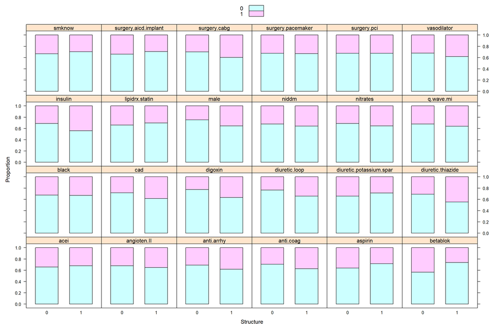

```r
##################################
# Creating a function to formulate
# the proportions table
##################################
EDA.PropTable.Function <- function(FactorVar) {
  EDA.Bar.Source.FactorVar <- EDA.Bar.Source[,c("died",
                                          FactorVar)]
  EDA.Bar.Source.FactorVar.Prop <- as.data.frame(prop.table(table(EDA.Bar.Source.FactorVar), 2))
  names(EDA.Bar.Source.FactorVar.Prop)[2] <- "Structure"
  EDA.Bar.Source.FactorVar.Prop$Variable <- rep(FactorVar,nrow(EDA.Bar.Source.FactorVar.Prop))

  return(EDA.Bar.Source.FactorVar.Prop)

}


EDA.Bar.Source.FactorVar.Prop.Group <- rbind(EDA.PropTable.Function(names(EDA.Bar.Source)[2]),
                                              EDA.PropTable.Function(names(EDA.Bar.Source)[3]),
                                              EDA.PropTable.Function(names(EDA.Bar.Source)[4]),
                                              EDA.PropTable.Function(names(EDA.Bar.Source)[5]),
                                              EDA.PropTable.Function(names(EDA.Bar.Source)[6]),
                                              EDA.PropTable.Function(names(EDA.Bar.Source)[7]),
                                              EDA.PropTable.Function(names(EDA.Bar.Source)[8]),
                                              EDA.PropTable.Function(names(EDA.Bar.Source)[9]),
                                              EDA.PropTable.Function(names(EDA.Bar.Source)[10]),
                                              EDA.PropTable.Function(names(EDA.Bar.Source)[11]),
                                              EDA.PropTable.Function(names(EDA.Bar.Source)[12]),
                                              EDA.PropTable.Function(names(EDA.Bar.Source)[13]),
                                              EDA.PropTable.Function(names(EDA.Bar.Source)[14]),
                                              EDA.PropTable.Function(names(EDA.Bar.Source)[15]),
                                              EDA.PropTable.Function(names(EDA.Bar.Source)[16]),
                                              EDA.PropTable.Function(names(EDA.Bar.Source)[17]),
                                              EDA.PropTable.Function(names(EDA.Bar.Source)[18]),
                                              EDA.PropTable.Function(names(EDA.Bar.Source)[19]),
                                              EDA.PropTable.Function(names(EDA.Bar.Source)[20]),
                                              EDA.PropTable.Function(names(EDA.Bar.Source)[21]),
                                              EDA.PropTable.Function(names(EDA.Bar.Source)[22]),
                                              EDA.PropTable.Function(names(EDA.Bar.Source)[23]),
                                              EDA.PropTable.Function(names(EDA.Bar.Source)[24]),
                                              EDA.PropTable.Function(names(EDA.Bar.Source)[25]))

(EDA.Barchart.FactorVar <- barchart(EDA.Bar.Source.FactorVar.Prop.Group[,3] ~
                                      EDA.Bar.Source.FactorVar.Prop.Group[,2] | EDA.Bar.Source.FactorVar.Prop.Group[,4],
                                      data=EDA.Bar.Source.FactorVar.Prop.Group,
                                      groups = EDA.Bar.Source.FactorVar.Prop.Group[,1],
                                      stack=TRUE,
                                      ylab = "Proportion",
                                      xlab = "Structure",
                                      auto.key = list(adj = 1),
                                      layout=(c(6,4))))
```

```r
##################################
# Formulating the Kaplan-Meier plots
# for the categorical variables
##################################
KM_PreModelling_Train <- PMA_PreModelling_Train
KM_PreModelling_Train$died <- as.numeric(KM_PreModelling_Train$died )

KM_betablok <- survfit(Surv(ttodead, died) ~ betablok,
                      data=KM_PreModelling_Train)
KMPlot_betablok <- ggsurvplot(KM_betablok,
                            xlab="Survival Time",
                            ylab="Survival Probability",
                            break.time.by=12,
                            ggtheme=theme_bw(),
                            fontsize=3,
                            pval.size=3,
                            pval=TRUE)

KM_aspirin <- survfit(Surv(ttodead, died) ~ aspirin,
                      data=KM_PreModelling_Train)
KMPlot_aspirin <- ggsurvplot(KM_aspirin,
                            xlab="Survival Time",
                            ylab="Survival Probability",
                            break.time.by=12,
                            ggtheme=theme_bw(),
                            fontsize=3,
                            pval.size=3,
                            pval=TRUE)

KM_anti.coag <- survfit(Surv(ttodead, died) ~ anti.coag,
                      data=KM_PreModelling_Train)
KMPlot_anti.coag <- ggsurvplot(KM_anti.coag,
                            xlab="Survival Time",
                            ylab="Survival Probability",
                            break.time.by=12,
                            ggtheme=theme_bw(),
                            fontsize=3,
                            pval.size=3,
                            pval=TRUE)

KM_anti.arrhy <- survfit(Surv(ttodead, died) ~ anti.arrhy,
                      data=KM_PreModelling_Train)
KMPlot_anti.arrhy <- ggsurvplot(KM_anti.arrhy,
                            xlab="Survival Time",
                            ylab="Survival Probability",
                            break.time.by=12,
                            ggtheme=theme_bw(),
                            fontsize=3,
                            pval.size=3,
                            pval=TRUE)

KM_angioten.II <- survfit(Surv(ttodead, died) ~ angioten.II,
                      data=KM_PreModelling_Train)
KMPlot_angioten.II <- ggsurvplot(KM_angioten.II,
                            xlab="Survival Time",
                            ylab="Survival Probability",
                            break.time.by=12,
                            ggtheme=theme_bw(),
                            fontsize=3,
                            pval.size=3,
                            pval=TRUE)

KM_acei <- survfit(Surv(ttodead, died) ~ acei,
                      data=KM_PreModelling_Train)
KMPlot_acei <- ggsurvplot(KM_acei,
                            xlab="Survival Time",
                            ylab="Survival Probability",
                            break.time.by=12,
                            ggtheme=theme_bw(),
                            fontsize=3,
                            pval.size=3,
                            pval=TRUE)

KM_diuretic.thiazide <- survfit(Surv(ttodead, died) ~ diuretic.thiazide,
                      data=KM_PreModelling_Train)
KMPlot_diuretic.thiazide <- ggsurvplot(KM_diuretic.thiazide,
                            xlab="Survival Time",
                            ylab="Survival Probability",
                            break.time.by=12,
                            ggtheme=theme_bw(),
                            fontsize=3,
                            pval.size=3,
                            pval=TRUE)

KM_diuretic.potassium.spar <- survfit(Surv(ttodead, died) ~ diuretic.potassium.spar,
                      data=KM_PreModelling_Train)
KMPlot_diuretic.potassium.spar <- ggsurvplot(KM_diuretic.potassium.spar,
                            xlab="Survival Time",
                            ylab="Survival Probability",
                            break.time.by=12,
                            ggtheme=theme_bw(),
                            fontsize=3,
                            pval.size=3,
                            pval=TRUE)

KM_diuretic.loop <- survfit(Surv(ttodead, died) ~ diuretic.loop,
                      data=KM_PreModelling_Train)
KMPlot_diuretic.loop <- ggsurvplot(KM_diuretic.loop,
                            xlab="Survival Time",
                            ylab="Survival Probability",
                            break.time.by=12,
                            ggtheme=theme_bw(),
                            fontsize=3,
                            pval.size=3,
                            pval=TRUE)

KM_digoxin <- survfit(Surv(ttodead, died) ~ digoxin,
                      data=KM_PreModelling_Train)
KMPlot_digoxin <- ggsurvplot(KM_digoxin,
                            xlab="Survival Time",
                            ylab="Survival Probability",
                            break.time.by=12,
                            ggtheme=theme_bw(),
                            fontsize=3,
                            pval.size=3,
                            pval=TRUE)

KM_cad <- survfit(Surv(ttodead, died) ~ cad,
                      data=KM_PreModelling_Train)
KMPlot_cad <- ggsurvplot(KM_cad,
                            xlab="Survival Time",
                            ylab="Survival Probability",
                            break.time.by=12,
                            ggtheme=theme_bw(),
                            fontsize=3,
                            pval.size=3,
                            pval=TRUE)

KM_black <- survfit(Surv(ttodead, died) ~ black,
                      data=KM_PreModelling_Train)
KMPlot_black <- ggsurvplot(KM_black,
                            xlab="Survival Time",
                            ylab="Survival Probability",
                            break.time.by=12,
                            ggtheme=theme_bw(),
                            fontsize=3,
                            pval.size=3,
                            pval=TRUE)

KM_q.wave.mi <- survfit(Surv(ttodead, died) ~ q.wave.mi,
                      data=KM_PreModelling_Train)
KMPlot_q.wave.mi <- ggsurvplot(KM_q.wave.mi,
                            xlab="Survival Time",
                            ylab="Survival Probability",
                            break.time.by=12,
                            ggtheme=theme_bw(),
                            fontsize=3,
                            pval.size=3,
                            pval=TRUE)
```

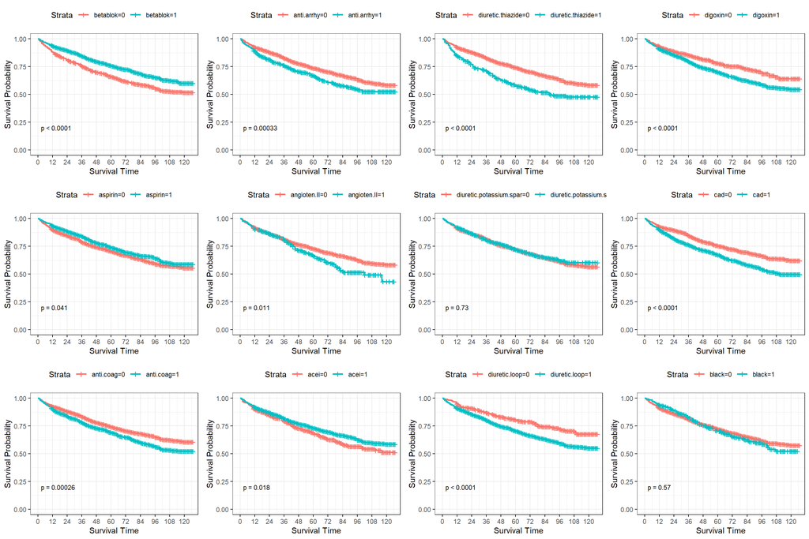

```r
KM_nitrates <- survfit(Surv(ttodead, died) ~ nitrates,
                      data=KM_PreModelling_Train)
KMPlot_nitrates <- ggsurvplot(KM_nitrates,
                            xlab="Survival Time",
                            ylab="Survival Probability",
                            break.time.by=12,
                            ggtheme=theme_bw(),
                            fontsize=3,
                            pval.size=3,
                            pval=TRUE)

KM_niddm <- survfit(Surv(ttodead, died) ~ niddm,
                      data=KM_PreModelling_Train)
KMPlot_niddm <- ggsurvplot(KM_niddm,
                            xlab="Survival Time",
                            ylab="Survival Probability",
                            break.time.by=12,
                            ggtheme=theme_bw(),
                            fontsize=3,
                            pval.size=3,
                            pval=TRUE)

KM_male <- survfit(Surv(ttodead, died) ~ male,
                      data=KM_PreModelling_Train)
KMPlot_male <- ggsurvplot(KM_male,
                            xlab="Survival Time",
                            ylab="Survival Probability",
                            break.time.by=12,
                            ggtheme=theme_bw(),
                            fontsize=3,
                            pval.size=3,
                            pval=TRUE)

KM_lipidrx.statin <- survfit(Surv(ttodead, died) ~ lipidrx.statin,
                      data=KM_PreModelling_Train)
KMPlot_lipidrx.statin <- ggsurvplot(KM_lipidrx.statin,
                            xlab="Survival Time",
                            ylab="Survival Probability",
                            break.time.by=12,
                            ggtheme=theme_bw(),
                            fontsize=3,
                            pval.size=3,
                            pval=TRUE)

KM_insulin <- survfit(Surv(ttodead, died) ~ insulin,
                      data=KM_PreModelling_Train)
KMPlot_insulin <- ggsurvplot(KM_insulin,
                            xlab="Survival Time",
                            ylab="Survival Probability",
                            break.time.by=12,
                            ggtheme=theme_bw(),
                            fontsize=3,
                            pval.size=3,
                            pval=TRUE)

KM_vasodilator <- survfit(Surv(ttodead, died) ~ vasodilator,
                      data=KM_PreModelling_Train)
KMPlot_vasodilator <- ggsurvplot(KM_vasodilator,
                            xlab="Survival Time",
                            ylab="Survival Probability",
                            break.time.by=12,
                            ggtheme=theme_bw(),
                            fontsize=3,
                            pval.size=3,
                            pval=TRUE)

KM_surgery.pci <- survfit(Surv(ttodead, died) ~ surgery.pci,
                      data=KM_PreModelling_Train)
KMPlot_surgery.pci <- ggsurvplot(KM_surgery.pci,
                            xlab="Survival Time",
                            ylab="Survival Probability",
                            break.time.by=12,
                            ggtheme=theme_bw(),
                            fontsize=3,
                            pval.size=3,
                            pval=TRUE)

KM_surgery.pacemaker <- survfit(Surv(ttodead, died) ~ surgery.pacemaker,
                      data=KM_PreModelling_Train)
KMPlot_surgery.pacemaker <- ggsurvplot(KM_surgery.pacemaker,
                            xlab="Survival Time",
                            ylab="Survival Probability",
                            break.time.by=12,
                            ggtheme=theme_bw(),
                            fontsize=3,
                            pval.size=3,
                            pval=TRUE)

KM_surgery.cabg <- survfit(Surv(ttodead, died) ~ surgery.cabg,
                      data=KM_PreModelling_Train)
KMPlot_surgery.cabg <- ggsurvplot(KM_surgery.cabg,
                            xlab="Survival Time",
                            ylab="Survival Probability",
                            break.time.by=12,
                            ggtheme=theme_bw(),
                            fontsize=3,
                            pval.size=3,
                            pval=TRUE)

KM_surgery.aicd.implant <- survfit(Surv(ttodead, died) ~ surgery.aicd.implant,
                      data=KM_PreModelling_Train)
KMPlot_surgery.aicd.implant <- ggsurvplot(KM_surgery.aicd.implant,
                            xlab="Survival Time",
                            ylab="Survival Probability",
                            break.time.by=12,
                            ggtheme=theme_bw(),
                            fontsize=3,
                            pval.size=3,
                            pval=TRUE)

KM_smknow <- survfit(Surv(ttodead, died) ~ smknow,
                      data=KM_PreModelling_Train)
KMPlot_smknow <- ggsurvplot(KM_smknow,
                            xlab="Survival Time",
                            ylab="Survival Probability",
                            break.time.by=12,
                            ggtheme=theme_bw(),
                            fontsize=3,
                            pval.size=3,
                            pval=TRUE)

KMPlot_List <- list()
KMPlot_List[[1]] <- KMPlot_betablok
KMPlot_List[[2]] <- KMPlot_aspirin
KMPlot_List[[3]] <- KMPlot_anti.coag
KMPlot_List[[4]] <- KMPlot_anti.arrhy
KMPlot_List[[5]] <- KMPlot_angioten.II
KMPlot_List[[6]] <- KMPlot_acei
KMPlot_List[[7]] <- KMPlot_diuretic.thiazide
KMPlot_List[[8]] <- KMPlot_diuretic.potassium.spar
KMPlot_List[[9]] <- KMPlot_diuretic.loop
KMPlot_List[[10]] <- KMPlot_digoxin
KMPlot_List[[11]] <- KMPlot_cad
KMPlot_List[[12]] <- KMPlot_black

arrange_ggsurvplots(KMPlot_List,
                    ncol=4,
                    nrow=3)
```

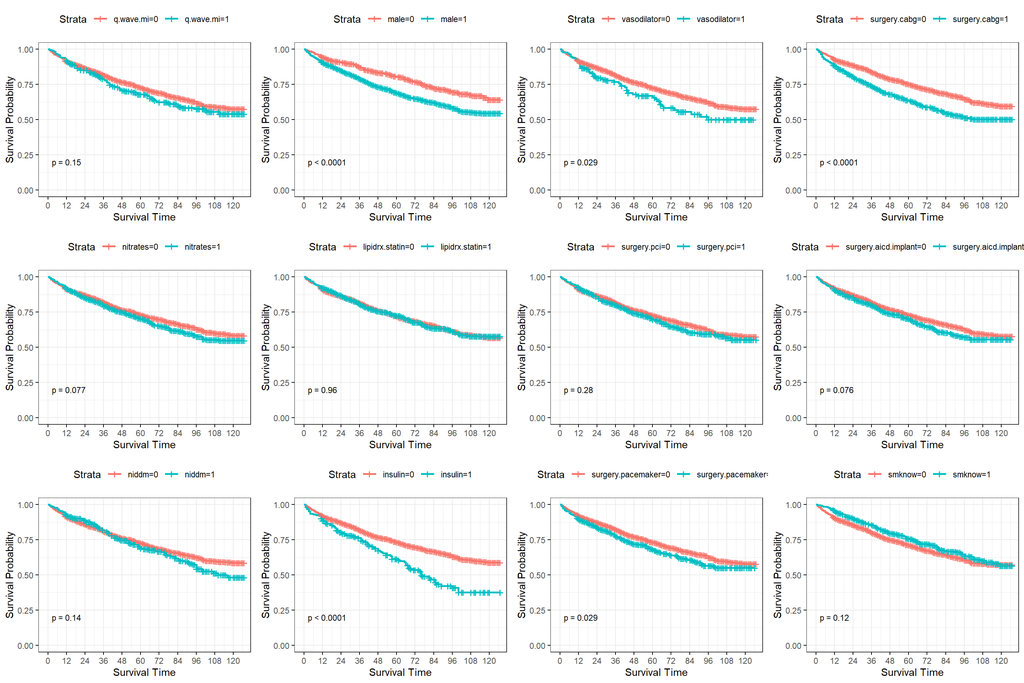

```r
KMPlot_List <- list()
KMPlot_List[[1]] <- KMPlot_q.wave.mi
KMPlot_List[[2]] <- KMPlot_nitrates
KMPlot_List[[3]] <- KMPlot_niddm
KMPlot_List[[4]] <- KMPlot_male
KMPlot_List[[5]] <- KMPlot_lipidrx.statin
KMPlot_List[[6]] <- KMPlot_insulin
KMPlot_List[[7]] <- KMPlot_vasodilator
KMPlot_List[[8]] <- KMPlot_surgery.pci
KMPlot_List[[9]] <- KMPlot_surgery.pacemaker
KMPlot_List[[10]] <- KMPlot_surgery.cabg
KMPlot_List[[11]] <- KMPlot_surgery.aicd.implant
KMPlot_List[[12]] <- KMPlot_smknow

arrange_ggsurvplots(KMPlot_List,
                    ncol=4,
                    nrow=3)
```

## 1.5 Survival Prediction Evaluation Metrics

### 1.5.1 Concordance Index (CIN)

[Concordance Index](https://jamanetwork.com/journals/jama/article-abstract/372568) is a rank correlation measure between a predictor and a possibly censored outcome with an event or censoring indicator. In survival analysis, a pair of patients is called concordant if the risk of the event predicted by a model is lower for the patient who experiences the event at a later time point. The concordance probability (C-index) is the frequency of concordant pairs among all pairs of subjects which can be used to measure and compare the discrimination power of risk prediction models.  
[Random Survival Forest](https://onlinelibrary.wiley.com/doi/abs/10.1002/sam.10103) builds an ensemble of tree-based learners based on different bootstrap samples of the original training data and only evaluates the split criterion compatible with censored survival times at each node for a randomly selected subset of features and thresholds. Final predictions are formed by aggregating the predictions of individual trees in the ensemble.  
[Cox Proportional Hazards](https://rss.onlinelibrary.wiley.com/doi/abs/10.1111/j.2517-6161.1972.tb00899.x) examines the relationship between a hazard function and a set of covariates by assuming that predictors act multiplicatively on the hazard function without any explicit assumption of its distributional form. The model is semi-parametric because while the baseline hazard can take any form, the covariates enter the model linearly.  
**[A]** The CIN metric was calculated for both the formulated Random Survival Forest (RSF) and Cox Proportional Hazards (CPH) models using the **SurvMetrics**, **randomForestSRC** and **survival** packages.  
**[B]** The RSF model contains 2 hyperparameters:  
**[B.1]** ntree = number of trees held constant at a value of 500.  
**[B.2]** nsplit = number of random splits for splitting a variable held constant at a value of 3.  
**[C]** The CPH model does not contain any hyperparameter.  
**[D]** The mean split-sample cross-validated CIN based on 25 iterations are summarized as follows: :  
**[D.1]** RSF = 0.68637  
**[D.2]** CPH = 0.69929  
**[D.3]** The range of cross-validated CIN metrics was relatively higher for the CPH model as compared to RSF model, indicating that CPH model had better model predictions.

**Code Chunk | Output**

```r
##################################
# Creating a local object
# for the train set
# using a numeric data type
# for all variables
##################################
MA_CIN <- peakVO2.Source[,names(peakVO2.Source) %in% c("ttodead",
                                                       "died",
                                                       "peak.vo2",
                                                       "bun",
                                                       "sodium",
                                                       "insulin",
                                                       "diuretic.thiazide",
                                                       "male")]

##################################
# Initializing data containers
# and random seed
##################################
set.seed(88888888)
RSF_Model_CIN = 0
CPH_Model_CIN = 0

for (i in 1:25) {
 ##################################
 # Formulating the train and test sets
 ##################################
 MA_CIN_Index = createFolds(1:nrow(MA_CIN), 2)
 MA_CIN_Train = MA_CIN[MA_CIN_Index[[1]],]
 MA_CIN_Test = MA_CIN[MA_CIN_Index[[2]],]

 ##################################
 # Formulating the Random Survival Forest model
 # and generating model predictions
 ##################################
 RSF_Model <-  rfsrc(Surv(ttodead, died)~.,
                   data = MA_CIN_Train,
                   nsplit = 3,
                   ntree = 500)
 RSF_Model_PredObject <- predict(RSF_Model, MA_CIN_Test)

 RSF_Model_Pred <- RSF_Model_PredObject$survival

 ##################################
 # Consolidating the ordered unique death times
 ##################################
 Ordered_Unique_Death_Time = RSF_Model$time.interest

 ##################################
 # Formulating the Cox Proportional Hazards model
 # and generating model predictions
 ##################################
 CPH_Model <-  coxph(Surv(ttodead, died)~.,
                     data = MA_CIN_Train,
                     x = TRUE)
 CPH_Model_Pred = predictSurvProb(CPH_Model,
                                  MA_CIN_Test,
                                  Ordered_Unique_Death_Time)

 ##################################
 # Calculating the Concordance Indices
 ##################################
 Median_Index <- median(1:length(Ordered_Unique_Death_Time))
 Survival_Object <- Surv(MA_CIN_Test$ttodead, MA_CIN_Test$died)

 RSF_Model_CIN[i] <- Cindex(Survival_Object,
                            predicted = RSF_Model_Pred[,Median_Index])

 CPH_Model_CIN[i] <- Cindex(Survival_Object,
                            predicted = CPH_Model_Pred[,Median_Index])

}

##################################
# Consolidating the repeated
# split-sample validated Concordance Indices
##################################
(SplitValidation_CIN = data.frame('CIN' = c(CPH_Model_CIN, RSF_Model_CIN),
                                 'Model' = c(rep('CPH', 25), rep('RSF', 25)),
                                 'Metric' = c(rep('CIN', 50))))
```

```
##         CIN Model Metric
## 1  0.700112   CPH    CIN
## 2  0.714396   CPH    CIN
## 3  0.702251   CPH    CIN
## 4  0.702791   CPH    CIN
## 5  0.677873   CPH    CIN
## 6  0.711866   CPH    CIN
## 7  0.689449   CPH    CIN
## 8  0.682214   CPH    CIN
## 9  0.709481   CPH    CIN
## 10 0.703413   CPH    CIN
## 11 0.713824   CPH    CIN
## 12 0.698661   CPH    CIN
## 13 0.717211   CPH    CIN
## 14 0.698832   CPH    CIN
```

[output cut: 36 more lines]

```r
(CPH_Model_CIN_CV <- mean(SplitValidation_CIN[SplitValidation_CIN$Model=="CPH",1]))
```

```
## [1] 0.6992913
```

```r
(RSF_Model_CIN_CV <- mean(SplitValidation_CIN[SplitValidation_CIN$Model=="RSF",1]))
```

```
## [1] 0.6863722
```

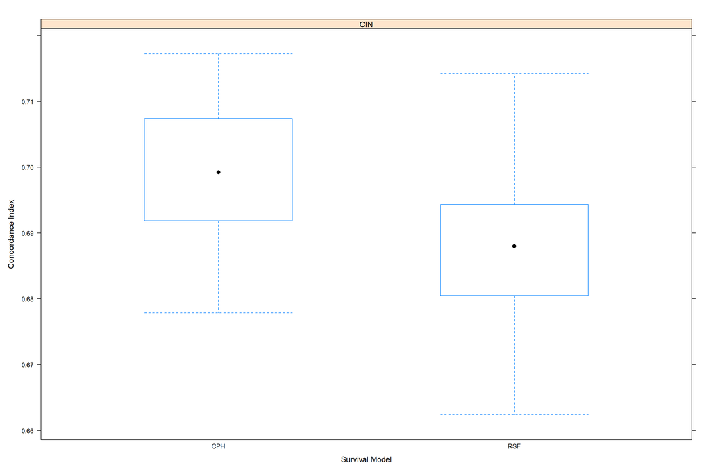

```r
(CIN_Boxplot <- bwplot(CIN ~ Model | Metric,
       data = SplitValidation_CIN,
       xlab = "Survival Model",
       ylab = "Concordance Index"))
```

### 1.5.2 Brier Score (BSC)

[Brier Score](https://journals.ametsoc.org/view/journals/mwre/78/1/1520-0493_1950_078_0001_vofeit_2_0_co_2.xml) is the mean square difference between the true classes and predicted probabilities. Serving as a a form of cost function, it is considered a proper score which means that it takes its minimal value only when the predicted probabilities match the empirical probabilities.  
[Random Survival Forest](https://onlinelibrary.wiley.com/doi/abs/10.1002/sam.10103) builds an ensemble of tree-based learners based on different bootstrap samples of the original training data and only evaluates the split criterion compatible with censored survival times at each node for a randomly selected subset of features and thresholds. Final predictions are formed by aggregating the predictions of individual trees in the ensemble.  
[Cox Proportional Hazards](https://rss.onlinelibrary.wiley.com/doi/abs/10.1111/j.2517-6161.1972.tb00899.x) examines the relationship between a hazard function and a set of covariates by assuming that predictors act multiplicatively on the hazard function without any explicit assumption of its distributional form. The model is semi-parametric because while the baseline hazard can take any form, the covariates enter the model linearly.  
**[A]** The BSC metric for the median survival time was calculated for both the formulated Random Survival Forest (RSF) and Cox Proportional Hazards (CPH) models using the **SurvMetrics**, **randomForestSRC** and **survival** packages.  
**[B]** The RSF model contains 2 hyperparameters:  
**[B.1]** ntree = number of trees held constant at a value of 500.  
**[B.2]** nsplit = number of random splits for splitting a variable held constant at a value of 3.  
**[C]** The CPH model does not contain any hyperparameter.  
**[D]** The average split-sample cross-validated BSC based on 25 iterations are summarized as follows: :  
**[D.1]** RSF = 2.07448  
**[D.2]** CPH = 1.98999  
**[D.3]** The range of cross-validated BSC metrics was relatively lower for the CPH model as compared to RSF model, indicating that CPH model had better model predictions.

**Code Chunk | Output**

```r
##################################
# Creating a local object
# for the train set
# using a numeric data type
# for all variables
##################################
MA_BSC <- peakVO2.Source[,names(peakVO2.Source) %in% c("ttodead",
                                                       "died",
                                                       "peak.vo2",
                                                       "bun",
                                                       "sodium",
                                                       "insulin",
                                                       "diuretic.thiazide",
                                                       "male")]

##################################
# Initializing data containers
# and random seed
##################################
set.seed(88888888)
RSF_Model_BSC = 0
CPH_Model_BSC = 0

for (i in 1:25) {
 ##################################
 # Formulating the train and test sets
 ##################################
 MA_BSC_Index = createFolds(1:nrow(MA_BSC), 2)
 MA_BSC_Train = MA_BSC[MA_BSC_Index[[1]],]
 MA_BSC_Test = MA_BSC[MA_BSC_Index[[2]],]

 ##################################
 # Formulating the Random Survival Forest model
 # and generating model predictions
 ##################################
 RSF_Model <-  rfsrc(Surv(ttodead, died)~.,
                   data = MA_BSC_Train,
                   nsplit = 3,
                   ntree = 500)
 RSF_Model_PredObject <- predict(RSF_Model, MA_BSC_Test)

 RSF_Model_Pred <- RSF_Model_PredObject$survival

 ##################################
 # Consolidating the ordered unique death times
 ##################################
 Ordered_Unique_Death_Time = RSF_Model$time.interest

 ##################################
 # Formulating the Cox Proportional Hazards model
 # and generating model predictions
 ##################################
 CPH_Model <-  coxph(Surv(ttodead, died)~.,
                     data = MA_BSC_Train,
                     x = TRUE)
 CPH_Model_Pred = predictSurvProb(CPH_Model,
                                  MA_BSC_Test,
                                  Ordered_Unique_Death_Time)

 ##################################
 # Calculating the Brier Scores
 ##################################
 Median_Index <- median(1:length(Ordered_Unique_Death_Time))
 Survival_Object <- Surv(MA_BSC_Test$ttodead, MA_BSC_Test$died)
 Median_DeathTime <- median(Ordered_Unique_Death_Time)

 RSF_Model_BSC[i] <- Brier(Survival_Object,
                           pre_sp = RSF_Model_Pred[,Median_Index],
                           Median_DeathTime)

 CPH_Model_BSC[i] <- Brier(Survival_Object,
                           pre_sp = CPH_Model_Pred[,Median_Index],
                           Median_DeathTime)

}

##################################
# Consolidating the repeated
# split-sample validated Brier Scores
##################################
(SplitValidation_BSC = data.frame('BSC' = c(CPH_Model_BSC, RSF_Model_BSC),
                                 'Model' = c(rep('CPH', 25), rep('RSF', 25)),
                                 'Metric' = c(rep('BSC', 50))))
```

```
##         BSC Model Metric
## 1  3.042685   CPH    BSC
## 2  2.823948   CPH    BSC
## 3  0.163000   CPH    BSC
## 4  5.653142   CPH    BSC
## 5  2.479632   CPH    BSC
## 6  0.154938   CPH    BSC
## 7  0.158088   CPH    BSC
## 8  0.158927   CPH    BSC
## 9  4.230457   CPH    BSC
## 10 6.025826   CPH    BSC
## 11 0.150234   CPH    BSC
## 12 0.167676   CPH    BSC
## 13 5.691130   CPH    BSC
## 14 0.160928   CPH    BSC
```

[output cut: 36 more lines]

```r
(CPH_Model_BSC_CV <- mean(SplitValidation_BSC[SplitValidation_BSC$Model=="CPH",1]))
```

```
## [1] 1.98999
```

```r
(RSF_Model_BSC_CV <- mean(SplitValidation_BSC[SplitValidation_BSC$Model=="RSF",1]))
```

```
## [1] 2.074489
```

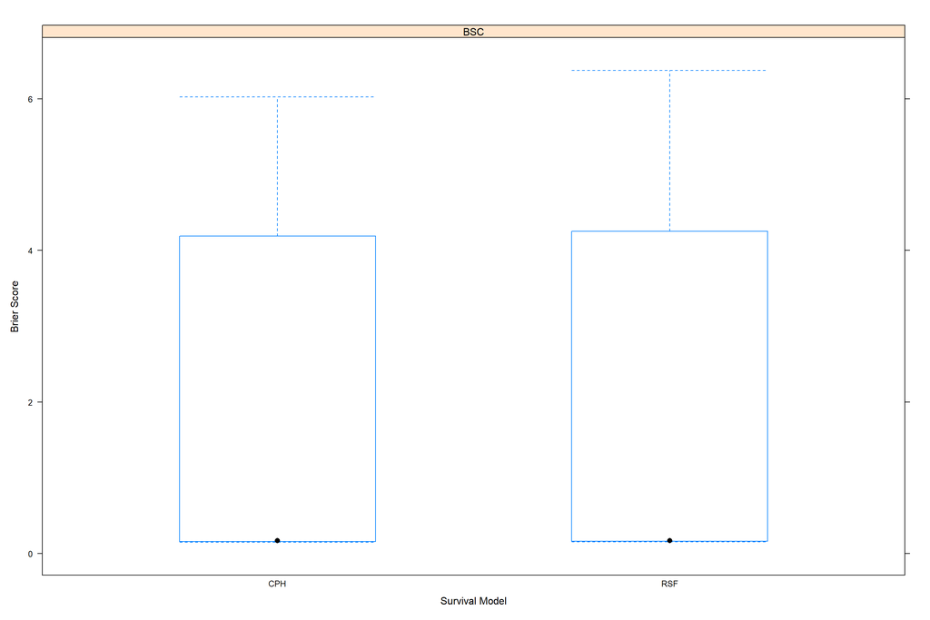

```r
(BSC_Boxplot <- bwplot(BSC ~ Model | Metric,
       data = SplitValidation_BSC,
       xlab = "Survival Model",
       ylab = "Brier Score"))
```

### 1.5.3 Integrated Absolute Error (IAE)

[Integrated Absolute Error](https://link.springer.com/article/10.1007/s10985-016-9372-1) is a type of continuous-time approach to continuous-time identification based on least-absolute errors.  
[Random Survival Forest](https://onlinelibrary.wiley.com/doi/abs/10.1002/sam.10103) builds an ensemble of tree-based learners based on different bootstrap samples of the original training data and only evaluates the split criterion compatible with censored survival times at each node for a randomly selected subset of features and thresholds. Final predictions are formed by aggregating the predictions of individual trees in the ensemble.  
[Cox Proportional Hazards](https://rss.onlinelibrary.wiley.com/doi/abs/10.1111/j.2517-6161.1972.tb00899.x) examines the relationship between a hazard function and a set of covariates by assuming that predictors act multiplicatively on the hazard function without any explicit assumption of its distributional form. The model is semi-parametric because while the baseline hazard can take any form, the covariates enter the model linearly.  
**[A]** The IAE metric for the survival time range was calculated for both the formulated Random Survival Forest (RSF) and Cox Proportional Hazards (CPH) models using the **SurvMetrics**, **randomForestSRC** and **survival** packages.  
**[B]** The RSF model contains 2 hyperparameters:  
**[B.1]** ntree = number of trees held constant at a value of 500.  
**[B.2]** nsplit = number of random splits for splitting a variable held constant at a value of 3.  
**[C]** The CPH model does not contain any hyperparameter.  
**[D]** The average split-sample cross-validated IAE based on 25 iterations are summarized as follows: :  
**[D.1]** RSF = 1.76058  
**[D.2]** CPH = 1.69852  
**[D.3]** The range of cross-validated IAE metrics was relatively lower for the CPH model as compared to RSF model, indicating that CPH model had better model predictions.

**Code Chunk | Output**

```r
##################################
# Creating a local object
# for the train set
# using a numeric data type
# for all variables
##################################
MA_IAE <- peakVO2.Source[,names(peakVO2.Source) %in% c("ttodead",
                                                       "died",
                                                       "peak.vo2",
                                                       "bun",
                                                       "sodium",
                                                       "insulin",
                                                       "diuretic.thiazide",
                                                       "male")]

##################################
# Initializing data containers
# and random seed
##################################
set.seed(88888888)
RSF_Model_IAE = 0
CPH_Model_IAE = 0

for (i in 1:25) {
 ##################################
 # Formulating the train and test sets
 ##################################
 MA_IAE_Index = createFolds(1:nrow(MA_IAE), 2)
 MA_IAE_Train = MA_IAE[MA_IAE_Index[[1]],]
 MA_IAE_Test = MA_IAE[MA_IAE_Index[[2]],]

 ##################################
 # Formulating the Random Survival Forest model
 # and generating model predictions
 ##################################
 RSF_Model <-  rfsrc(Surv(ttodead, died)~.,
                   data = MA_IAE_Train,
                   nsplit = 3,
                   ntree = 500)
 RSF_Model_PredObject <- predict(RSF_Model, MA_IAE_Test)

 RSF_Model_Pred <- RSF_Model_PredObject$survival

 ##################################
 # Consolidating the ordered unique death times
 ##################################
 Ordered_Unique_Death_Time = RSF_Model$time.interest

 ##################################
 # Formulating the Cox Proportional Hazards model
 # and generating model predictions
 ##################################
 CPH_Model <-  coxph(Surv(ttodead, died)~.,
                     data = MA_IAE_Train,
                     x = TRUE)
 CPH_Model_Pred = predictSurvProb(CPH_Model,
                                  MA_IAE_Test,
                                  Ordered_Unique_Death_Time)

 ##################################
 # Calculating the Integrated Absolute Errors
 ##################################
 Median_Index <- median(1:length(Ordered_Unique_Death_Time))
 Survival_Object <- Surv(MA_IAE_Test$ttodead, MA_IAE_Test$died)

 RSF_Model_IE     <- IAEISE(Survival_Object,
                          sp_matrix = RSF_Model_Pred,
                          Ordered_Unique_Death_Time)

 RSF_Model_IAE[i] <- RSF_Model_IE[1]

 CPH_Model_IE     <- IAEISE(Survival_Object,
                          sp_matrix = CPH_Model_Pred,
                          Ordered_Unique_Death_Time)

 CPH_Model_IAE[i] <- CPH_Model_IE[1]

}

##################################
# Consolidating the repeated
# split-sample validated Integrated Absolute Errors
##################################
(SplitValidation_IAE = data.frame('IAE' = c(CPH_Model_IAE, RSF_Model_IAE),
                                 'Model' = c(rep('CPH', 25), rep('RSF', 25)),
                                 'Metric' = c(rep('IAE', 50))))
```

```
##       IAE Model Metric
## 1  3.7202   CPH    IAE
## 2  1.9355   CPH    IAE
## 3  1.2259   CPH    IAE
## 4  1.9123   CPH    IAE
## 5  0.6668   CPH    IAE
## 6  1.2670   CPH    IAE
## 7  2.0430   CPH    IAE
## 8  1.1436   CPH    IAE
## 9  1.8833   CPH    IAE
## 10 1.5042   CPH    IAE
## 11 2.7417   CPH    IAE
## 12 2.4253   CPH    IAE
## 13 1.5415   CPH    IAE
## 14 1.6989   CPH    IAE
```

[output cut: 36 more lines]

```r
(CPH_Model_IAE_CV <- mean(SplitValidation_IAE[SplitValidation_IAE$Model=="CPH",1]))
```

```
## [1] 1.698528
```

```r
(RSF_Model_IAE_CV <- mean(SplitValidation_IAE[SplitValidation_IAE$Model=="RSF",1]))
```

```
## [1] 1.760588
```

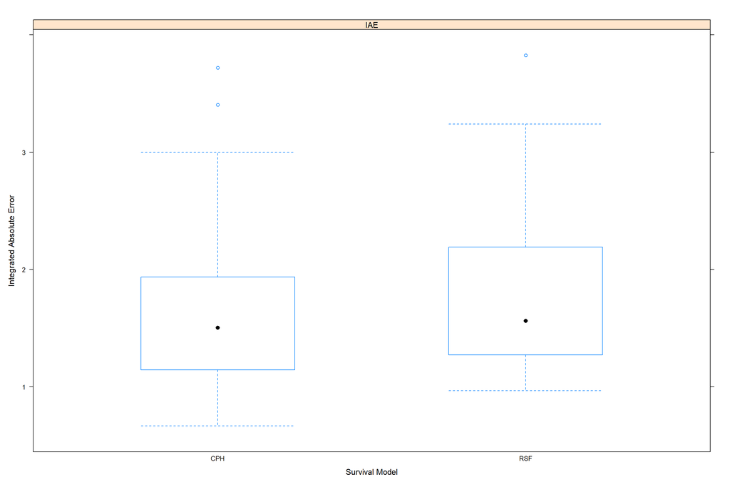

```r
(IAE_Boxplot <- bwplot(IAE ~ Model | Metric,
       data = SplitValidation_IAE,
       xlab = "Survival Model",
       ylab = "Integrated Absolute Error"))
```

### 1.5.4 Integrated Square Error (ISE)

**Code Chunk | Output**

```r
##################################
# Creating a local object
# for the train set
# using a numeric data type
# for all variables
##################################
MA_ISE <- peakVO2.Source[,names(peakVO2.Source) %in% c("ttodead",
                                                       "died",
                                                       "peak.vo2",
                                                       "bun",
                                                       "sodium",
                                                       "insulin",
                                                       "diuretic.thiazide",
                                                       "male")]

##################################
# Initializing data containers
# and random seed
##################################
set.seed(88888888)
RSF_Model_ISE = 0
CPH_Model_ISE = 0

for (i in 1:25) {
 ##################################
 # Formulating the train and test sets
 ##################################
 MA_ISE_Index = createFolds(1:nrow(MA_ISE), 2)
 MA_ISE_Train = MA_ISE[MA_ISE_Index[[1]],]
 MA_ISE_Test = MA_ISE[MA_ISE_Index[[2]],]

 ##################################
 # Formulating the Random Survival Forest model
 # and generating model predictions
 ##################################
 RSF_Model <-  rfsrc(Surv(ttodead, died)~.,
                   data = MA_ISE_Train,
                   nsplit = 3,
                   ntree = 500)
 RSF_Model_PredObject <- predict(RSF_Model, MA_ISE_Test)

 RSF_Model_Pred <- RSF_Model_PredObject$survival

 ##################################
 # Consolidating the ordered unique death times
 ##################################
 Ordered_Unique_Death_Time = RSF_Model$time.interest

 ##################################
 # Formulating the Cox Proportional Hazards model
 # and generating model predictions
 ##################################
 CPH_Model <-  coxph(Surv(ttodead, died)~.,
                     data = MA_ISE_Train,
                     x = TRUE)
 CPH_Model_Pred = predictSurvProb(CPH_Model,
                                  MA_ISE_Test,
                                  Ordered_Unique_Death_Time)

 ##################################
 # Calculating the Integrated Square Error
 ##################################
 Median_Index <- median(1:length(Ordered_Unique_Death_Time))
 Survival_Object <- Surv(MA_ISE_Test$ttodead, MA_ISE_Test$died)

 RSF_Model_IE     <- IAEISE(Survival_Object,
                          sp_matrix = RSF_Model_Pred,
                          Ordered_Unique_Death_Time)

 RSF_Model_ISE[i] <- RSF_Model_IE[2]

 CPH_Model_IE     <- IAEISE(Survival_Object,
                          sp_matrix = CPH_Model_Pred,
                          Ordered_Unique_Death_Time)

 CPH_Model_ISE[i] <- CPH_Model_IE[2]

}

##################################
# Consolidating the repeated
# split-sample validated Integrated Square Error
##################################
(SplitValidation_ISE = data.frame('ISE' = c(CPH_Model_ISE, RSF_Model_ISE),
                                 'Model' = c(rep('CPH', 25), rep('RSF', 25)),
                                 'Metric' = c(rep('ISE', 50))))
```

```
##       ISE Model Metric
## 1  0.1511   CPH    ISE
## 2  0.0435   CPH    ISE
## 3  0.0211   CPH    ISE
## 4  0.0496   CPH    ISE
## 5  0.0067   CPH    ISE
## 6  0.0186   CPH    ISE
## 7  0.0500   CPH    ISE
## 8  0.0199   CPH    ISE
## 9  0.0358   CPH    ISE
## 10 0.0236   CPH    ISE
## 11 0.0805   CPH    ISE
## 12 0.0672   CPH    ISE
## 13 0.0265   CPH    ISE
## 14 0.0433   CPH    ISE
```

[output cut: 36 more lines]

```r
(CPH_Model_ISE_CV <- mean(SplitValidation_ISE[SplitValidation_ISE$Model=="CPH",1]))
```

```
## [1] 0.041916
```

```r
(RSF_Model_ISE_CV <- mean(SplitValidation_ISE[SplitValidation_ISE$Model=="RSF",1]))
```

```
## [1] 0.043424
```

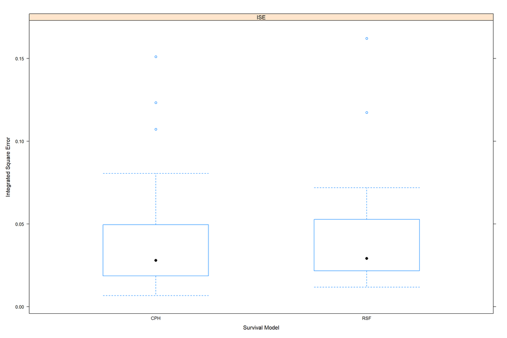

```r
(ISE_Boxplot <- bwplot(ISE ~ Model | Metric,
       data = SplitValidation_ISE,
       xlab = "Survival Model",
       ylab = "Integrated Square Error"))
```

## 1.6 Consolidated Findings

**[A]** All performance evaluation metrics for survival prediction showed consistent results in terms of identifying the CPH model as better performing than the RSF model. The conditions with which the usage for each metric will vary, will depend on their intended application and/or current data restrictions.  
**[A.1]** **CIN : Concordance Index** (**SurvMetrics** package) evaluates the survival model’s discriminative ability through rank correlation. It is the most commonly used survival model evaluation metric which is a generalization of the Receiver Operating Characteristics (ROC) curve in the case of a complete survival data. While it is an intuitive measure of model discrimination, it diminishes the effect of tied survival data. Updated versions of the metric apply methods to address this data restriction.  
**[A.2]** **BSC : Brier Score** (**SurvMetrics** package) evaluates the true survival state of an observation and the predicted survival probability at a given time point. However, it is restricted by the selection of only a specific time point (normally assigned as the median of the observation time). Different selection methods may also have large differences in the evaluation of the model’s prediction effect. There is an updated version of the metric called the Integrated Brier Score which computes the metric for the entire time range, but may be computationally exhaustive.  
**[A.3]** **IAE | ISE : Integrated Absolute and Square Errors** (**SurvMetrics** package) evaluates the true and predicted survival functions. However, in practical applications, the mathematical expression of the survival function is usually unknown, which results to existing IAE and ISE metrics to be only used in simulation experiments. There is however the alternative to obtain the approximate expression of the survival function using the non-parametric KM estimation method, if the current analysis allows such leniency in assumptions.

**Code Chunk | Output**

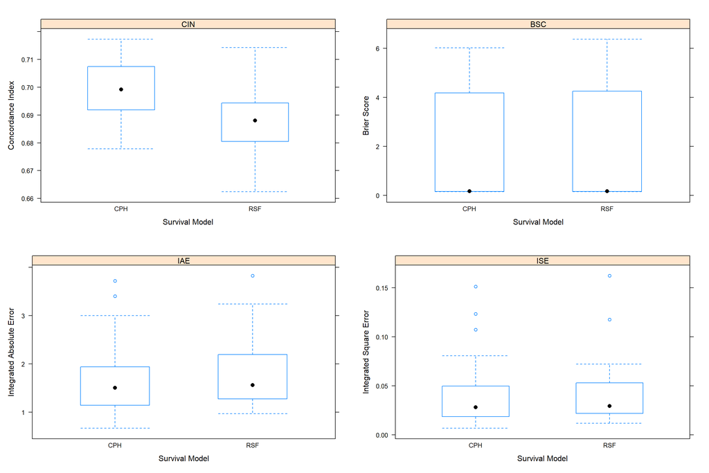

```r
################################################################################
# Consolidating all performance metric results
################################################################################
grid.arrange(CIN_Boxplot,
             BSC_Boxplot,
             IAE_Boxplot,
             ISE_Boxplot,
             ncol = 2)
```

# **2. Summary**

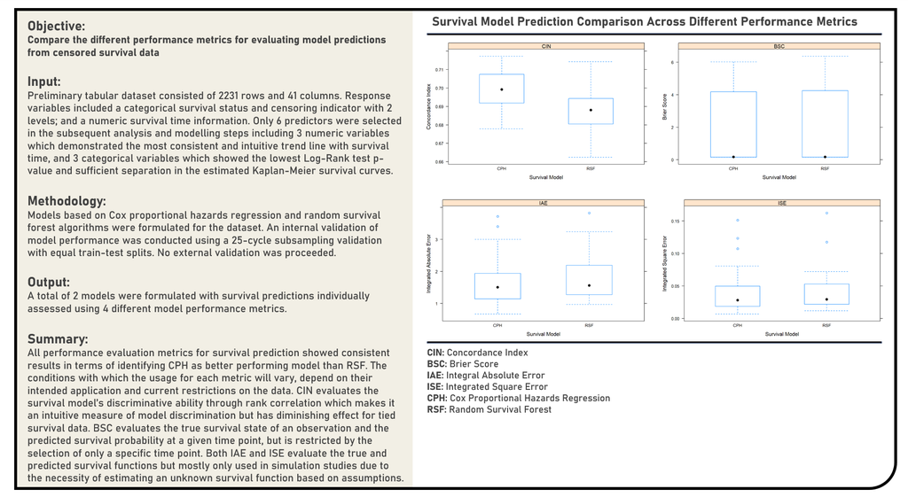

# **3. References**

**[Book]** [Clinical Prediction Models](http://clinicalpredictionmodels.org/) by Ewout Steyerberg  
**[Book]** [Survival Analysis: A Self-Learning Text](https://link.springer.com/book/10.1007/978-1-4419-6646-9/) by David Kleinbaum and Mitchel Klein  
**[Book]** [Applied Survival Analysis Using R](https://link.springer.com/book/10.1007/978-3-319-31245-3/) by Dirk Moore  
**[Book]** [Regression Modeling Strategies](https://link.springer.com/book/10.1007/978-3-319-19425-7/) by Frank Harrell  
**[Book]** [R for Health Data Science](https://argoshare.is.ed.ac.uk/healthyr_book/) by Ewen Harrison and Riinu Pius  
**[Book]** [Supervised Machine Learning](https://bookdown.org/mpfoley1973/supervised-ml/) by Michael Foley  
**[Book]** [Data Science for Biological, Medical and Health Research](https://thomaselove.github.io/432-notes/index.html) by Thomas Love  
**[R Package]** [survival](https://cran.microsoft.com/snapshot/2022-04-01/web/packages/survival/index.html/) by Terry Therneau  
**[R Package]** [survminer](https://cran.r-project.org/web/packages/survminer/index.html/) by Alboukadel Kassambara  
**[R Package]** [mice](https://www.gerkovink.com/miceVignettes/) by Gerko Vink and Stef van Buuren  
**[R Package]** [foreign](https://cran.r-project.org/web/packages/foreign/index.html/) by R Core Team  
**[R Package]** [rms](https://cran.r-project.org/web/packages/rms/index.html/) by Frank Harrell  
**[R Package]** [Hmisc](https://cran.r-project.org/web/packages/Hmisc//) by Frank Harrell and Charles Dupont  
**[R Package]** [VIM](https://cran.r-project.org/web/packages/VIM/index.html/) by Matthias Templ  
**[R Package]** [gridExtra](https://cran.microsoft.com/snapshot/2017-08-01/web/packages/gridExtra/index.html/) by Baptiste Auguie  
**[R Package]** [finalfit](https://cran.r-project.org/web/packages/finalfit/index.html/) by Ewen Harrison  
**[R Package]** [knitr](https://cran.r-project.org/web/packages/knitr/index.html/) by Yihui Xie  
**[R Package]** [dplyr](https://cran.r-project.org/web/packages/dplyr/index.html/) by Hadley Wickham  
**[R Package]** [gtsummary](https://cran.r-project.org/web/packages/gtsummary/index.html/) by Daniel Sjoberg  
**[R Package]** [tidyr](https://cran.r-project.org/web/packages/tidyr/index.html/) by Hadley Wickham  
**[R Package]** [purrr](https://cran.r-project.org/web/packages/purrr//) by Lionel Henry  
**[R Package]** [moments](https://cran.r-project.org/web/packages/moments/index.html) by Lukasz Komsta and Frederick Novomestky  
**[R Package]** [skimr](https://cran.r-project.org/web/packages/skimr/skimr.pdf) by Elin Waring  
**[R Package]** [caret](https://topepo.github.io/caret/index.html) by Max Kuhn  
**[R Package]** [corrplot](https://cran.r-project.org/web/packages/corrplot/corrplot.pdf) by Taiyun Wei  
**[R Package]** [SurvMetrics](https://cran.r-project.org/web/packages/SurvMetrics/SurvMetrics.pdf) by Hanpu Zhou  
**[R Package]** [randomForestSRC](https://cran.r-project.org/web/packages/randomForestSRC/randomForestSRC.pdf) by Hemant Ishwaran and Udaya Kogalur  
**[R Package]** [pec](https://cran.r-project.org/web/packages/pec/pec.pdf) by Thomas Gerds  
**[Article]** [Predictive Evaluation Metrics in Survival Analysis](https://cran.r-project.org/web/packages/SurvMetrics/vignettes/SurvMetrics-vignette.html) by Zhou Hanpu  
**[Article]** [Random Survival Forests](https://www.randomforestsrc.org/articles/survival.html) by Hemant Ishwaran  
**[Article]** [Survival Analysis](https://sphweb.bumc.bu.edu/otlt/MPH-Modules/BS/BS704_Survival/index.html) by Lisa Sullivan  
**[Article]** [Survival Analysis in R](https://www.emilyzabor.com/tutorials/survival_analysis_in_r_tutorial.html) by Emily Zabor  
**[Article]** [Assessment of Discrimination in Survival Analysis](https://rstudio-pubs-static.s3.amazonaws.com/3506_36a9509e9d544386bd3e69de30bca608.html) by R-Studio Team  
**[Article]** [Cox Proportional-Hazards Regression](https://www.medcalc.org/manual/cox-regression.php) by MedCalc Team  
**[Article]** [Cox Proportional-Hazards Model](https://rstudio-pubs-static.s3.amazonaws.com/3506_36a9509e9d544386bd3e69de30bca608.html) by R Studio Team  
**[Article]** [Exploring Time To Event / Survival Data](https://thomaselove.github.io/432-notes/exploring-time-to-event-survival-data.html) by Thomas Love  
**[Article]** [Survival Analysis](http://www.sthda.com/english/wiki/survival-analysis) by Alboukadel Kassambara  
**[Article]** [Survival Analysis with R](https://rviews.rstudio.com/2017/09/25/survival-analysis-with-r/) by Joseph Rickert  
**[Article]** [Cox Model Assumptions](http://www.sthda.com/english/wiki/cox-model-assumptions#testing-non-linearity) by Alboukadel Kassambara  
**[Article]** [Understanding Predictions in Survival Analysis](https://scikit-survival.readthedocs.io/en/stable/user_guide/understanding_predictions.html) by Scikit Team  
**[Publication]** [Survival Analysis Part I: Basic Concepts and First Analyses](https://www.ncbi.nlm.nih.gov/pmc/articles/PMC2394262/) by Taane Clark (British Journal of Cancer)  
**[Publication]** [Survival Analysis Part II: Multivariate Data Analysis – An Introduction to Concepts and Methods](https://www.ncbi.nlm.nih.gov/pmc/articles/PMC2394368/) by Mike Bradburn (British Journal of Cancer)  
**[Publication]** [Survival Analysis Part III: Multivariate Data Analysis – Choosing a Model and Assessing its Adequacy and Fit](https://www.ncbi.nlm.nih.gov/pmc/articles/PMC2376927/) by Mike Bradburn (British Journal of Cancer)  
**[Publication]** [Survival Analysis Part IV: Further Concepts and Methods in Survival Analysis](https://www.ncbi.nlm.nih.gov/pmc/articles/PMC2394469/) by Taane Clark (British Journal of Cancer)  
**[Publication]** [Evaluating the Yield of Medical Tests](https://jamanetwork.com/journals/jama/article-abstract/372568) by Frank Harrell, Robert Califf, David Pryor, Kerry Lee and Robert Rosati (Journal of the American Medical Association)  
**[Publication]** [Verification of Forecasts Expressed in Terms of Probability](https://journals.ametsoc.org/view/journals/mwre/78/1/1520-0493_1950_078_0001_vofeit_2_0_co_2.xml) by Glenn Brier (Monthly Weather Review)  
**[Publication]** [A New Measure of Prognostic Separation in Survival Data](https://onlinelibrary.wiley.com/doi/10.1002/sim.1621) by Patrick Royston and Willi Sauerbrei (Statistics in Medicine)  
**[Publication]** [L1 Splitting Rules in Survival Forests](https://link.springer.com/article/10.1007/s10985-016-9372-1) by Hoora Moradian, Denis Larocque and François Bellavance (Lifetime Data Analysis)  
**[Publication]** [Integrated Square Error of Hazard Rate Estimation for Survival Data with Missing Censoring Indicators](https://link.springer.com/article/10.1007/s11424-021-9307-0) by Yuye Zou, Guoliang Fan and Riquan Zhang (Journal of Systems Science and Complexity)  
**[Publication]** [The Explained Variation in Proportional Hazards Regression](https://www.jstor.org/stable/2336066) by Michael Schemper (Biometrika)  
**[Publication]** [Random Survival Forests for High-Dimensional Data](https://onlinelibrary.wiley.com/doi/abs/10.1002/sam.10103) by Hemant Ishwaran, Udaya Kogalur, Xi Chen and Andy Minn (Statistical Analysis and Data Mining)  
**[Publication]** [Regression Models and Life-Tables](https://rss.onlinelibrary.wiley.com/doi/abs/10.1111/j.2517-6161.1972.tb00899.x) by David Cox (Royal Statistical Society)  
**[Tutorial]** [Survival Analysis / Time-To-Event Analysis in R](https://campus.datacamp.com/courses/survival-analysis-in-r/what-is-survival-analysis?ex=1) by Heidi Seibold (Datacamp)